# Gunjan_B76_submission

## I. Problem Description

### Predict if the Merchant is Fraudster or not for an e-commerce client

#### ‘XYZ’ is a large e-commerce company with its operations in several countries. As the online giant grows, so has the number of fraudster merchants are. They deliver counterfeits or, in some cases, nothing at all. Such schemes leave customers duped, and place both legitimate merchants and the company itself in a constant battle to rid the marketplace of scammers. Determining this is also important in budgeting for fraud investigation. It's a well-known problem both to the company and to merchants, which they say hasn't effectively addressed the issue. They are serious about it and want to protect themselves from these fraudulent merchants using technology.

#### You are expected to create an analytical and modelling framework to predict the Merchant Fraudulency(yes/no) based on the quantitative and qualitative features provided in the dataset while answering other questions too cited below.

## Problem Statement

Predict if the Merchant is Fraudster or not for an e-commerce client

## Mounting Google Drive

Mounting google drive to access files

```python
from google.colab import drive
drive.mount('/gdrive')
```

## Importing Library

```python
import os
import numpy as np
import pandas as pd

from sklearn import preprocessing
from sklearn.impute import SimpleImputer

from sklearn.compose import ColumnTransformer

from sklearn.preprocessing import StandardScaler
from sklearn.preprocessing import OneHotEncoder
from sklearn.model_selection import train_test_split
from sklearn.pipeline import Pipeline
from sklearn.model_selection import GridSearchCV, cross_val_score, StratifiedKFold, RandomizedSearchCV

from sklearn.tree import DecisionTreeClassifier
from sklearn.ensemble import RandomForestClassifier
from sklearn.svm import SVC
from sklearn.linear_model import LogisticRegression

from sklearn.ensemble import GradientBoostingClassifier
from sklearn.ensemble import AdaBoostClassifier
from sklearn.metrics import confusion_matrix
import pandas_profiling
import matplotlib.pyplot as plt
import seaborn as sns

from imblearn.over_sampling import SMOTE
from sklearn.metrics import accuracy_score, recall_score, precision_score
```

##### load training data

```python
train_order=pd.read_csv("/gdrive/My Drive/MITH/ProblemDescription_and_Dataset/train_order_data.csv")
train_merchant=pd.read_csv("/gdrive/My Drive/MITH/ProblemDescription_and_Dataset/train_merchant_data.csv")
traindata=pd.read_csv("/gdrive/My Drive/MITH/ProblemDescription_and_Dataset/train.csv")
```

Overview

Dataset info

| Number of variables | 7 |
| --- | --- |
| Number of observations | 54213 |
| Total Missing (%) | 0.0% |
| Total size in memory | 2.9 MiB |
| Average record size in memory | 56.0 B |

Variables types

| Numeric | 3 |
| --- | --- |
| Categorical | 3 |
| Boolean | 0 |
| Date | 0 |
| Text (Unique) | 1 |
| Rejected | 0 |
| Unsupported | 0 |

Warnings

- `Date_of_Order` has a high cardinality: 54161 distinct values Warning

Variables

Customer_ID  
Numeric

| Distinct count | 34081 |
| --- | --- |
| Unique (%) | 62.9% |
| Missing (%) | 0.0% |
| Missing (n) | 0 |
| Infinite (%) | 0.0% |
| Infinite (n) | 0 |

| Mean | 137970 |
| --- | --- |
| Minimum | 111234 |
| Maximum | 165000 |
| Zeros (%) | 0.0% |

Toggle details

**Statistics**

Quantile statistics

| Minimum | 111234 |
| --- | --- |
| 5-th percentile | 113840 |
| Q1 | 124470 |
| Median | 137860 |
| Q3 | 151400 |
| 95-th percentile | 162400 |
| Maximum | 165000 |
| Range | 53766 |
| Interquartile range | 26934 |

Descriptive statistics

| Standard deviation | 15564 |
| --- | --- |
| Coef of variation | 0.11281 |
| Kurtosis | -1.203 |
| Mean | 137970 |
| MAD | 13489 |
| Skewness | 0.012789 |
| Sum | 7479566220 |
| Variance | 242220000 |
| Memory size | 423.7 KiB |

**Histogram**

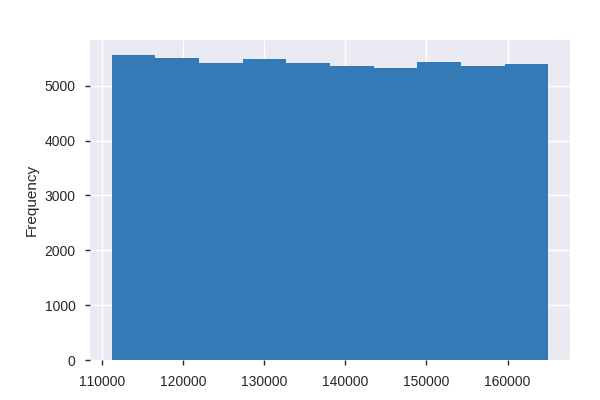

**Common Values**

| Value | Count | Frequency (%) |  |
| --- | --- | --- | --- |
| 154763 | 7 | 0.0% |  |
| 124702 | 7 | 0.0% |  |
| 111658 | 7 | 0.0% |  |
| 156576 | 7 | 0.0% |  |
| 113846 | 6 | 0.0% |  |
| 161878 | 6 | 0.0% |  |
| 152990 | 6 | 0.0% |  |
| 148560 | 6 | 0.0% |  |
| 143061 | 6 | 0.0% |  |
| 145537 | 6 | 0.0% |  |
| Other values (34071) | 54149 | 99.9% |  |

**Extreme Values**

Minimum 5 values

| Value | Count | Frequency (%) |  |
| --- | --- | --- | --- |
| 111234 | 2 | 0.0% |  |
| 111235 | 2 | 0.0% |  |
| 111239 | 4 | 0.0% |  |
| 111240 | 1 | 0.0% |  |
| 111241 | 4 | 0.0% |  |

Maximum 5 values

| Value | Count | Frequency (%) |  |
| --- | --- | --- | --- |
| 164995 | 1 | 0.0% |  |
| 164996 | 2 | 0.0% |  |
| 164997 | 1 | 0.0% |  |
| 164998 | 1 | 0.0% |  |
| 165000 | 1 | 0.0% |  |

Order_ID  
Categorical, Unique

| First 3 values |
| --- |
| ce78d64b3e1b |
| cf5c1732b736 |
| 238aad428bb9 |

| Last 3 values |
| --- |
| 9521a9d14bba |
| b8ee7844e934 |
| ed32e3a513b6 |

Toggle details

First 10 values

| Value | Count | Frequency (%) |  |
| --- | --- | --- | --- |
| 00004e323a70 | 1 | 0.0% |  |
| 0000e3a872c0 | 1 | 0.0% |  |
| 0001409236ad | 1 | 0.0% |  |
| 0001572f3c53 | 1 | 0.0% |  |
| 0001bd1afcbf | 1 | 0.0% |  |

Last 10 values

| Value | Count | Frequency (%) |  |
| --- | --- | --- | --- |
| fff89e8f3a57 | 1 | 0.0% |  |
| fff96670338f | 1 | 0.0% |  |
| fffe8353a8f2 | 1 | 0.0% |  |
| ffff19a176c9 | 1 | 0.0% |  |
| ffff961ce6cb | 1 | 0.0% |  |

Date_of_Order  
Categorical

| Distinct count | 54161 |
| --- | --- |
| Unique (%) | 99.9% |
| Missing (%) | 0.0% |
| Missing (n) | 0 |

| 2018-09-30 05:46:55 | 2 |
| --- | --- |
| 2018-05-13 13:29:28 | 2 |
| 2018-05-07 20:38:43 | 2 |
| Other values (54158) | 54207 |

Toggle details

| Value | Count | Frequency (%) |  |
| --- | --- | --- | --- |
| 2018-09-30 05:46:55 | 2 | 0.0% |  |
| 2018-05-13 13:29:28 | 2 | 0.0% |  |
| 2018-05-07 20:38:43 | 2 | 0.0% |  |
| 2018-01-15 02:10:17 | 2 | 0.0% |  |
| 2018-03-24 18:31:44 | 2 | 0.0% |  |
| 2018-07-28 07:55:27 | 2 | 0.0% |  |
| 2018-07-26 04:06:37 | 2 | 0.0% |  |
| 2018-05-09 11:22:28 | 2 | 0.0% |  |
| 2018-06-21 08:33:35 | 2 | 0.0% |  |
| 2018-08-05 13:16:48 | 2 | 0.0% |  |
| Other values (54151) | 54193 | 100.0% |  |

Order_Value_USD  
Numeric

| Distinct count | 116 |
| --- | --- |
| Unique (%) | 0.2% |
| Missing (%) | 0.0% |
| Missing (n) | 0 |
| Infinite (%) | 0.0% |
| Infinite (n) | 0 |

| Mean | 92.23 |
| --- | --- |
| Minimum | 22 |
| Maximum | 385 |
| Zeros (%) | 0.0% |

Toggle details

**Statistics**

Quantile statistics

| Minimum | 22 |
| --- | --- |
| 5-th percentile | 30 |
| Q1 | 55 |
| Median | 88 |
| Q3 | 122 |
| 95-th percentile | 175 |
| Maximum | 385 |
| Range | 363 |
| Interquartile range | 67 |

Descriptive statistics

| Standard deviation | 45.673 |
| --- | --- |
| Coef of variation | 0.49521 |
| Kurtosis | 0.13089 |
| Mean | 92.23 |
| MAD | 37.11 |
| Skewness | 0.66474 |
| Sum | 5000078 |
| Variance | 2086 |
| Memory size | 423.7 KiB |

**Histogram**

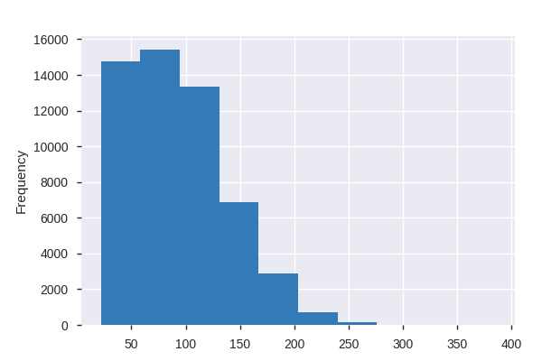

**Common Values**

| Value | Count | Frequency (%) |  |
| --- | --- | --- | --- |
| 65 | 1167 | 2.2% |  |
| 58 | 1152 | 2.1% |  |
| 88 | 1151 | 2.1% |  |
| 80 | 1145 | 2.1% |  |
| 70 | 1140 | 2.1% |  |
| 60 | 1133 | 2.1% |  |
| 68 | 1114 | 2.1% |  |
| 72 | 1111 | 2.0% |  |
| 85 | 1109 | 2.0% |  |
| 55 | 1108 | 2.0% |  |
| Other values (106) | 42883 | 79.1% |  |

**Extreme Values**

Minimum 5 values

| Value | Count | Frequency (%) |  |
| --- | --- | --- | --- |
| 22 | 837 | 1.5% |  |
| 25 | 822 | 1.5% |  |
| 28 | 844 | 1.6% |  |
| 30 | 886 | 1.6% |  |
| 32 | 915 | 1.7% |  |

Maximum 5 values

| Value | Count | Frequency (%) |  |
| --- | --- | --- | --- |
| 305 | 1 | 0.0% |  |
| 308 | 1 | 0.0% |  |
| 320 | 1 | 0.0% |  |
| 322 | 1 | 0.0% |  |
| 385 | 1 | 0.0% |  |

Order_Source  
Categorical

| Distinct count | 3 |
| --- | --- |
| Unique (%) | 0.0% |
| Missing (%) | 0.0% |
| Missing (n) | 0 |

| SEO | 21884 |
| --- | --- |
| Ads | 21259 |
| Direct | 11070 |

Toggle details

| Value | Count | Frequency (%) |  |
| --- | --- | --- | --- |
| SEO | 21884 | 40.4% |  |
| Ads | 21259 | 39.2% |  |
| Direct | 11070 | 20.4% |  |

Order_Payment_Method  
Categorical

| Distinct count | 5 |
| --- | --- |
| Unique (%) | 0.0% |
| Missing (%) | 0.0% |
| Missing (n) | 0 |

| Credit Card | 21844 |
| --- | --- |
| Internet Banking | 13193 |
| Debit Card | 9070 |
| Other values (2) | 10106 |

Toggle details

| Value | Count | Frequency (%) |  |
| --- | --- | --- | --- |
| Credit Card | 21844 | 40.3% |  |
| Internet Banking | 13193 | 24.3% |  |
| Debit Card | 9070 | 16.7% |  |
| E-wallet | 8739 | 16.1% |  |
| Cash On Delivery | 1367 | 2.5% |  |

Merchant_ID  
Numeric

| Distinct count | 54213 |
| --- | --- |
| Unique (%) | 100.0% |
| Missing (%) | 0.0% |
| Missing (n) | 0 |
| Infinite (%) | 0.0% |
| Infinite (n) | 0 |

| Mean | 200400 |
| --- | --- |
| Minimum | 2 |
| Maximum | 399993 |
| Zeros (%) | 0.0% |

Toggle details

**Statistics**

Quantile statistics

| Minimum | 2 |
| --- | --- |
| 5-th percentile | 20237 |
| Q1 | 101000 |
| Median | 200570 |
| Q3 | 300410 |
| 95-th percentile | 379870 |
| Maximum | 399993 |
| Range | 399991 |
| Interquartile range | 199410 |

Descriptive statistics

| Standard deviation | 115400 |
| --- | --- |
| Coef of variation | 0.57585 |
| Kurtosis | -1.1988 |
| Mean | 200400 |
| MAD | 99939 |
| Skewness | -0.003282 |
| Sum | 10864023688 |
| Variance | 13317000000 |
| Memory size | 423.7 KiB |

**Histogram**

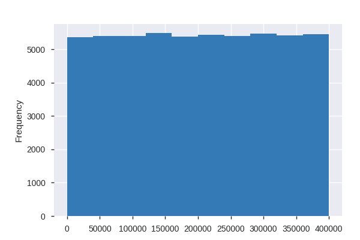

**Common Values**

| Value | Count | Frequency (%) |  |
| --- | --- | --- | --- |
| 264191 | 1 | 0.0% |  |
| 47749 | 1 | 0.0% |  |
| 158872 | 1 | 0.0% |  |
| 53226 | 1 | 0.0% |  |
| 7318 | 1 | 0.0% |  |
| 263317 | 1 | 0.0% |  |
| 265364 | 1 | 0.0% |  |
| 13459 | 1 | 0.0% |  |
| 222771 | 1 | 0.0% |  |
| 142480 | 1 | 0.0% |  |
| Other values (54203) | 54203 | 100.0% |  |

**Extreme Values**

Minimum 5 values

| Value | Count | Frequency (%) |  |
| --- | --- | --- | --- |
| 2 | 1 | 0.0% |  |
| 4 | 1 | 0.0% |  |
| 33 | 1 | 0.0% |  |
| 41 | 1 | 0.0% |  |
| 44 | 1 | 0.0% |  |

Maximum 5 values

| Value | Count | Frequency (%) |  |
| --- | --- | --- | --- |
| 399965 | 1 | 0.0% |  |
| 399971 | 1 | 0.0% |  |
| 399987 | 1 | 0.0% |  |
| 399992 | 1 | 0.0% |  |
| 399993 | 1 | 0.0% |  |

Correlations

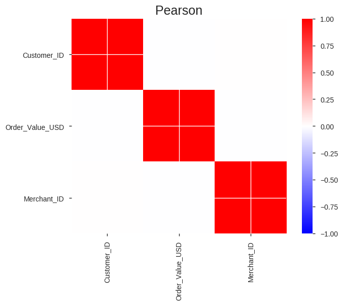

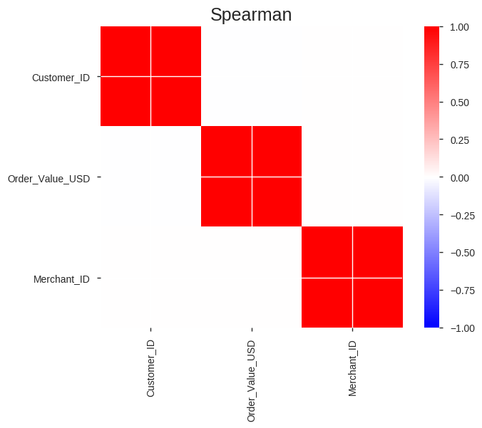

Sample

|  | Customer_ID | Order_ID | Date_of_Order | Order_Value_USD | Order_Source | Order_Payment_Method | Merchant_ID |
| --- | --- | --- | --- | --- | --- | --- | --- |
| 0 | 126221 | 37cea9512f8d | 2018-04-29 16:39:26 | 148 | Direct | Credit Card | 124231 |
| 1 | 115471 | 09f12e6efde2 | 2018-06-16 17:05:40 | 145 | SEO | Credit Card | 136178 |
| 2 | 151786 | 4e69e956e159 | 2018-10-26 18:00:46 | 62 | Ads | Internet Banking | 198611 |
| 3 | 140456 | 663443aaeb82 | 2018-12-12 05:41:52 | 28 | SEO | Debit Card | 127993 |
| 4 | 114721 | 99258810c121 | 2018-09-20 11:06:10 | 70 | Ads | Credit Card | 250146 |

```python
pandas_profiling.ProfileReport(train_order)
```

Overview

Dataset info

| Number of variables | 7 |
| --- | --- |
| Number of observations | 54213 |
| Total Missing (%) | 0.0% |
| Total size in memory | 2.9 MiB |
| Average record size in memory | 56.0 B |

Variables types

| Numeric | 2 |
| --- | --- |
| Categorical | 3 |
| Boolean | 0 |
| Date | 0 |
| Text (Unique) | 1 |
| Rejected | 1 |
| Unsupported | 0 |

Warnings

- `Ecommerce_Provider_ID` has constant value 1746213 Rejected

- `Registered_Device_ID` has a high cardinality: 51291 distinct values Warning

- `IP_Address` has a high cardinality: 52028 distinct values Warning

Variables

Ecommerce_Provider_ID  
Constant

*This variable is constant and should be ignored for analysis*

| Constant value | 1746213 |
| --- | --- |

Merchant_ID  
Numeric

| Distinct count | 54213 |
| --- | --- |
| Unique (%) | 100.0% |
| Missing (%) | 0.0% |
| Missing (n) | 0 |
| Infinite (%) | 0.0% |
| Infinite (n) | 0 |

| Mean | 200400 |
| --- | --- |
| Minimum | 2 |
| Maximum | 399993 |
| Zeros (%) | 0.0% |

Toggle details

**Statistics**

Quantile statistics

| Minimum | 2 |
| --- | --- |
| 5-th percentile | 20237 |
| Q1 | 101000 |
| Median | 200570 |
| Q3 | 300410 |
| 95-th percentile | 379870 |
| Maximum | 399993 |
| Range | 399991 |
| Interquartile range | 199410 |

Descriptive statistics

| Standard deviation | 115400 |
| --- | --- |
| Coef of variation | 0.57585 |
| Kurtosis | -1.1988 |
| Mean | 200400 |
| MAD | 99939 |
| Skewness | -0.003282 |
| Sum | 10864023688 |
| Variance | 13317000000 |
| Memory size | 423.7 KiB |

**Histogram**

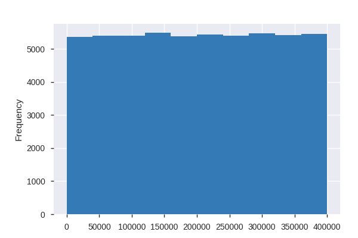

**Common Values**

| Value | Count | Frequency (%) |  |
| --- | --- | --- | --- |
| 264191 | 1 | 0.0% |  |
| 357435 | 1 | 0.0% |  |
| 343154 | 1 | 0.0% |  |
| 280057 | 1 | 0.0% |  |
| 119919 | 1 | 0.0% |  |
| 248940 | 1 | 0.0% |  |
| 136480 | 1 | 0.0% |  |
| 242787 | 1 | 0.0% |  |
| 113762 | 1 | 0.0% |  |
| 109664 | 1 | 0.0% |  |
| Other values (54203) | 54203 | 100.0% |  |

**Extreme Values**

Minimum 5 values

| Value | Count | Frequency (%) |  |
| --- | --- | --- | --- |
| 2 | 1 | 0.0% |  |
| 4 | 1 | 0.0% |  |
| 33 | 1 | 0.0% |  |
| 41 | 1 | 0.0% |  |
| 44 | 1 | 0.0% |  |

Maximum 5 values

| Value | Count | Frequency (%) |  |
| --- | --- | --- | --- |
| 399965 | 1 | 0.0% |  |
| 399971 | 1 | 0.0% |  |
| 399987 | 1 | 0.0% |  |
| 399992 | 1 | 0.0% |  |
| 399993 | 1 | 0.0% |  |

Merchant_Registration_Date  
Categorical, Unique

| First 3 values |
| --- |
| 2018-07-06 19:12:45 |
| 2018-06-07 20:49:09 |
| 2018-06-22 22:24:04 |

| Last 3 values |
| --- |
| 2018-01-22 08:12:25 |
| 2018-05-10 04:27:16 |
| 2018-03-31 21:25:45 |

Toggle details

First 10 values

| Value | Count | Frequency (%) |  |
| --- | --- | --- | --- |
| 2018-01-01 00:00:45 | 1 | 0.0% |  |
| 2018-01-01 00:00:47 | 1 | 0.0% |  |
| 2018-01-01 00:00:48 | 1 | 0.0% |  |
| 2018-01-01 00:00:50 | 1 | 0.0% |  |
| 2018-01-01 00:05:19 | 1 | 0.0% |  |

Last 10 values

| Value | Count | Frequency (%) |  |
| --- | --- | --- | --- |
| 2018-08-18 04:09:10 | 1 | 0.0% |  |
| 2018-08-18 04:12:27 | 1 | 0.0% |  |
| 2018-08-18 04:29:35 | 1 | 0.0% |  |
| 2018-08-18 04:31:11 | 1 | 0.0% |  |
| 2018-08-18 04:40:29 | 1 | 0.0% |  |

Registered_Device_ID  
Categorical

| Distinct count | 51291 |
| --- | --- |
| Unique (%) | 94.6% |
| Missing (%) | 0.0% |
| Missing (n) | 0 |

| VGGTRBYDZMCPN | 9 |
| --- | --- |
| USYRYIUTYSOKD | 9 |
| KJEKRMHEHLUOR | 9 |
| Other values (51288) | 54186 |

Toggle details

| Value | Count | Frequency (%) |  |
| --- | --- | --- | --- |
| VGGTRBYDZMCPN | 9 | 0.0% |  |
| USYRYIUTYSOKD | 9 | 0.0% |  |
| KJEKRMHEHLUOR | 9 | 0.0% |  |
| RJEAMRBBMPWEA | 9 | 0.0% |  |
| VIPZYJGMVMXOF | 9 | 0.0% |  |
| TCFHYPEGJMBIZ | 9 | 0.0% |  |
| QGWUOPUHKKOWQ | 9 | 0.0% |  |
| RDLIARTBSYNJX | 9 | 0.0% |  |
| AZPFJFPBMDWHC | 9 | 0.0% |  |
| LTTKUWBKITCUC | 8 | 0.0% |  |
| Other values (51281) | 54124 | 99.8% |  |

Gender  
Categorical

| Distinct count | 2 |
| --- | --- |
| Unique (%) | 0.0% |
| Missing (%) | 0.0% |
| Missing (n) | 0 |

| M | 31761 |
| --- | --- |
| F | 22452 |

Toggle details

| Value | Count | Frequency (%) |  |
| --- | --- | --- | --- |
| M | 31761 | 58.6% |  |
| F | 22452 | 41.4% |  |

Age  
Numeric

| Distinct count | 53 |
| --- | --- |
| Unique (%) | 0.1% |
| Missing (%) | 0.0% |
| Missing (n) | 0 |
| Infinite (%) | 0.0% |
| Infinite (n) | 0 |

| Mean | 33.122 |
| --- | --- |
| Minimum | 18 |
| Maximum | 72 |
| Zeros (%) | 0.0% |

Toggle details

**Statistics**

Quantile statistics

| Minimum | 18 |
| --- | --- |
| 5-th percentile | 20 |
| Q1 | 27 |
| Median | 32 |
| Q3 | 39 |
| 95-th percentile | 48 |
| Maximum | 72 |
| Range | 54 |
| Interquartile range | 12 |

Descriptive statistics

| Standard deviation | 8.6301 |
| --- | --- |
| Coef of variation | 0.26055 |
| Kurtosis | -0.17797 |
| Mean | 33.122 |
| MAD | 6.9995 |
| Skewness | 0.43186 |
| Sum | 1795656 |
| Variance | 74.478 |
| Memory size | 423.7 KiB |

**Histogram**

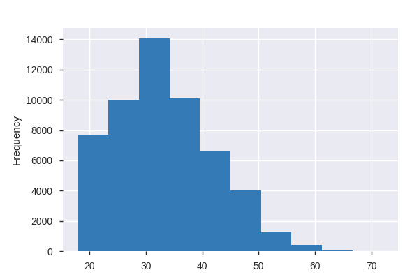

**Common Values**

| Value | Count | Frequency (%) |  |
| --- | --- | --- | --- |
| 32 | 2460 | 4.5% |  |
| 31 | 2399 | 4.4% |  |
| 29 | 2326 | 4.3% |  |
| 33 | 2316 | 4.3% |  |
| 34 | 2279 | 4.2% |  |
| 28 | 2279 | 4.2% |  |
| 30 | 2274 | 4.2% |  |
| 35 | 2242 | 4.1% |  |
| 36 | 2208 | 4.1% |  |
| 27 | 2090 | 3.9% |  |
| Other values (43) | 31340 | 57.8% |  |

**Extreme Values**

Minimum 5 values

| Value | Count | Frequency (%) |  |
| --- | --- | --- | --- |
| 18 | 1004 | 1.9% |  |
| 19 | 1077 | 2.0% |  |
| 20 | 1238 | 2.3% |  |
| 21 | 1329 | 2.5% |  |
| 22 | 1376 | 2.5% |  |

Maximum 5 values

| Value | Count | Frequency (%) |  |
| --- | --- | --- | --- |
| 66 | 4 | 0.0% |  |
| 67 | 3 | 0.0% |  |
| 68 | 2 | 0.0% |  |
| 69 | 2 | 0.0% |  |
| 72 | 1 | 0.0% |  |

IP_Address  
Categorical

| Distinct count | 52028 |
| --- | --- |
| Unique (%) | 96.0% |
| Missing (%) | 0.0% |
| Missing (n) | 0 |

| 136.189.191.154 | 9 |
| --- | --- |
| 115.241.135.193 | 9 |
| 137.29.157.65 | 9 |
| Other values (52025) | 54186 |

Toggle details

| Value | Count | Frequency (%) |  |
| --- | --- | --- | --- |
| 136.189.191.154 | 9 | 0.0% |  |
| 115.241.135.193 | 9 | 0.0% |  |
| 137.29.157.65 | 9 | 0.0% |  |
| 107.136.93.76 | 9 | 0.0% |  |
| 32.67.159.62 | 9 | 0.0% |  |
| 66.198.113.69 | 9 | 0.0% |  |
| 91.161.239.48 | 9 | 0.0% |  |
| 107.29.25.29 | 9 | 0.0% |  |
| 175.104.225.24 | 9 | 0.0% |  |
| 220.0.17.177 | 8 | 0.0% |  |
| Other values (52018) | 54124 | 99.8% |  |

Correlations

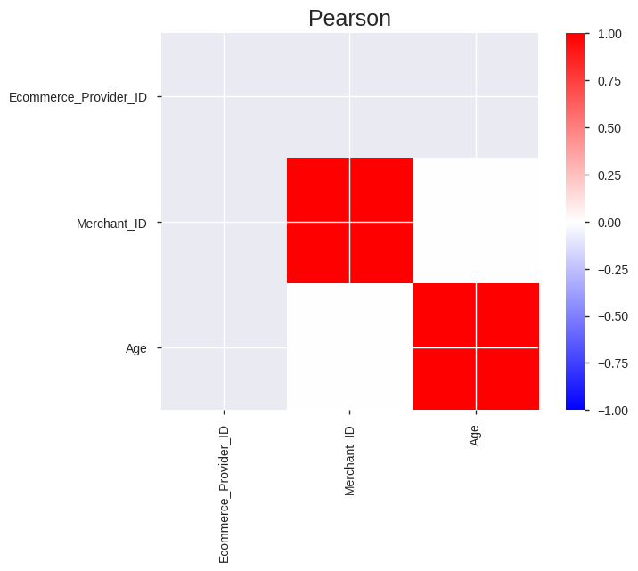

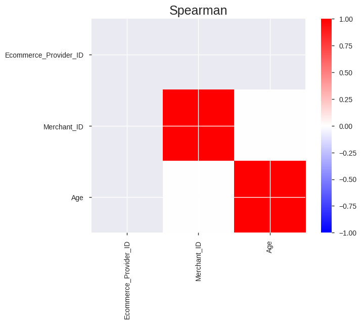

Sample

|  | Ecommerce_Provider_ID | Merchant_ID | Merchant_Registration_Date | Registered_Device_ID | Gender | Age | IP_Address |
| --- | --- | --- | --- | --- | --- | --- | --- |
| 0 | 1746213 | 50448 | 2018-05-01 21:15:11 | VATQMMZTVOZUT | F | 39 | 48.151.136.76 |
| 1 | 1746213 | 338754 | 2018-04-14 10:13:00 | LJCILLBRQZNKS | M | 35 | 94.9.145.169 |
| 2 | 1746213 | 291127 | 2018-06-20 07:44:22 | JFVHSUGKDAYZV | F | 40 | 58.94.157.121 |
| 3 | 1746213 | 319919 | 2018-06-27 01:41:39 | WFRXMPLQYXRMY | M | 37 | 193.187.41.186 |
| 4 | 1746213 | 195911 | 2018-01-05 00:55:41 | GGHKWMSWHCMID | F | 27 | 125.96.20.172 |

```python
pandas_profiling.ProfileReport(train_merchant)
```

Loading all the three csv files given: train_order, train_merchant, train

##### load test data

```python
test_order=pd.read_csv("/gdrive/My Drive/MITH/ProblemDescription_and_Dataset/test_order_data.csv")
test_merchant=pd.read_csv("/gdrive/My Drive/MITH/ProblemDescription_and_Dataset/test_merchant_data.csv")
```

Overview

Dataset info

| Number of variables | 7 |
| --- | --- |
| Number of observations | 13554 |
| Total Missing (%) | 0.0% |
| Total size in memory | 741.4 KiB |
| Average record size in memory | 56.0 B |

Variables types

| Numeric | 3 |
| --- | --- |
| Categorical | 3 |
| Boolean | 0 |
| Date | 0 |
| Text (Unique) | 1 |
| Rejected | 0 |
| Unsupported | 0 |

Warnings

- `Date_of_Order` has a high cardinality: 13548 distinct values Warning

Variables

Customer_ID  
Numeric

| Distinct count | 11975 |
| --- | --- |
| Unique (%) | 88.4% |
| Missing (%) | 0.0% |
| Missing (n) | 0 |
| Infinite (%) | 0.0% |
| Infinite (n) | 0 |

| Mean | 138090 |
| --- | --- |
| Minimum | 111252 |
| Maximum | 165000 |
| Zeros (%) | 0.0% |

Toggle details

**Statistics**

Quantile statistics

| Minimum | 111252 |
| --- | --- |
| 5-th percentile | 113790 |
| Q1 | 124420 |
| Median | 138300 |
| Q3 | 151370 |
| 95-th percentile | 162390 |
| Maximum | 165000 |
| Range | 53748 |
| Interquartile range | 26954 |

Descriptive statistics

| Standard deviation | 15565 |
| --- | --- |
| Coef of variation | 0.11272 |
| Kurtosis | -1.1981 |
| Mean | 138090 |
| MAD | 13471 |
| Skewness | -0.0072928 |
| Sum | 1871651671 |
| Variance | 242280000 |
| Memory size | 106.0 KiB |

**Histogram**

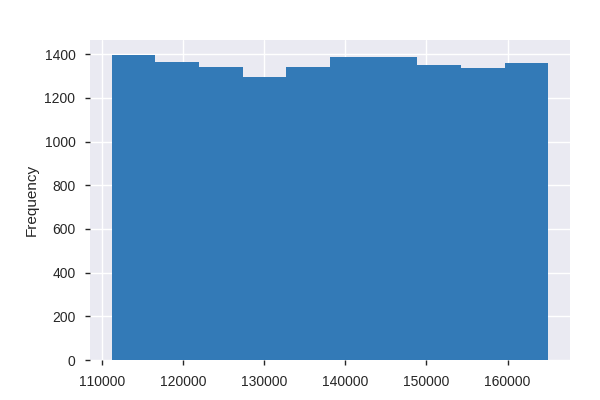

**Common Values**

| Value | Count | Frequency (%) |  |
| --- | --- | --- | --- |
| 139271 | 4 | 0.0% |  |
| 145181 | 4 | 0.0% |  |
| 147868 | 4 | 0.0% |  |
| 153531 | 4 | 0.0% |  |
| 119751 | 4 | 0.0% |  |
| 111357 | 4 | 0.0% |  |
| 163948 | 3 | 0.0% |  |
| 121979 | 3 | 0.0% |  |
| 135303 | 3 | 0.0% |  |
| 164984 | 3 | 0.0% |  |
| Other values (11965) | 13518 | 99.7% |  |

**Extreme Values**

Minimum 5 values

| Value | Count | Frequency (%) |  |
| --- | --- | --- | --- |
| 111252 | 1 | 0.0% |  |
| 111257 | 1 | 0.0% |  |
| 111259 | 1 | 0.0% |  |
| 111261 | 1 | 0.0% |  |
| 111267 | 2 | 0.0% |  |

Maximum 5 values

| Value | Count | Frequency (%) |  |
| --- | --- | --- | --- |
| 164994 | 1 | 0.0% |  |
| 164995 | 1 | 0.0% |  |
| 164997 | 1 | 0.0% |  |
| 164998 | 1 | 0.0% |  |
| 165000 | 1 | 0.0% |  |

Order_ID  
Categorical, Unique

| First 3 values |
| --- |
| 58aebacce99c |
| 98180e168448 |
| 4c83c94cdba5 |

| Last 3 values |
| --- |
| 65eeb2ed96b7 |
| 918c91ff1171 |
| ec9022c6c23a |

Toggle details

First 10 values

| Value | Count | Frequency (%) |  |
| --- | --- | --- | --- |
| 0000fb139236 | 1 | 0.0% |  |
| 00019169fa4c | 1 | 0.0% |  |
| 000ae8e9aaf4 | 1 | 0.0% |  |
| 000d6363eab8 | 1 | 0.0% |  |
| 000e1a1d64cd | 1 | 0.0% |  |

Last 10 values

| Value | Count | Frequency (%) |  |
| --- | --- | --- | --- |
| ffd8485bdd9c | 1 | 0.0% |  |
| ffde5a3bf598 | 1 | 0.0% |  |
| fff0330e819c | 1 | 0.0% |  |
| fff1a5426525 | 1 | 0.0% |  |
| fff5851a893a | 1 | 0.0% |  |

Date_of_Order  
Categorical

| Distinct count | 13548 |
| --- | --- |
| Unique (%) | 100.0% |
| Missing (%) | 0.0% |
| Missing (n) | 0 |

| 2018-04-17 09:00:37 | 2 |
| --- | --- |
| 2018-09-24 15:44:21 | 2 |
| 2018-06-24 01:04:30 | 2 |
| Other values (13545) | 13548 |

Toggle details

| Value | Count | Frequency (%) |  |
| --- | --- | --- | --- |
| 2018-04-17 09:00:37 | 2 | 0.0% |  |
| 2018-09-24 15:44:21 | 2 | 0.0% |  |
| 2018-06-24 01:04:30 | 2 | 0.0% |  |
| 2018-05-08 15:52:37 | 2 | 0.0% |  |
| 2018-09-19 20:20:18 | 2 | 0.0% |  |
| 2018-09-22 04:29:01 | 2 | 0.0% |  |
| 2018-05-23 06:39:47 | 1 | 0.0% |  |
| 2018-05-14 04:32:20 | 1 | 0.0% |  |
| 2018-09-26 17:32:55 | 1 | 0.0% |  |
| 2018-10-02 09:39:49 | 1 | 0.0% |  |
| Other values (13538) | 13538 | 99.9% |  |

Order_Value_USD  
Numeric

| Distinct count | 105 |
| --- | --- |
| Unique (%) | 0.8% |
| Missing (%) | 0.0% |
| Missing (n) | 0 |
| Infinite (%) | 0.0% |
| Infinite (n) | 0 |

| Mean | 92.494 |
| --- | --- |
| Minimum | 22 |
| Maximum | 320 |
| Zeros (%) | 0.0% |

Toggle details

**Statistics**

Quantile statistics

| Minimum | 22 |
| --- | --- |
| 5-th percentile | 30 |
| Q1 | 58 |
| Median | 88 |
| Q3 | 122 |
| 95-th percentile | 178 |
| Maximum | 320 |
| Range | 298 |
| Interquartile range | 64 |

Descriptive statistics

| Standard deviation | 45.945 |
| --- | --- |
| Coef of variation | 0.49674 |
| Kurtosis | 0.22456 |
| Mean | 92.494 |
| MAD | 37.201 |
| Skewness | 0.69946 |
| Sum | 1253657 |
| Variance | 2110.9 |
| Memory size | 106.0 KiB |

**Histogram**

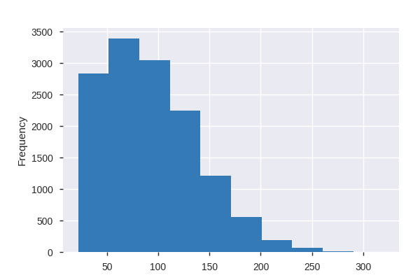

**Common Values**

| Value | Count | Frequency (%) |  |
| --- | --- | --- | --- |
| 70 | 330 | 2.4% |  |
| 68 | 299 | 2.2% |  |
| 75 | 294 | 2.2% |  |
| 58 | 291 | 2.1% |  |
| 62 | 287 | 2.1% |  |
| 65 | 287 | 2.1% |  |
| 45 | 280 | 2.1% |  |
| 78 | 280 | 2.1% |  |
| 55 | 277 | 2.0% |  |
| 72 | 275 | 2.0% |  |
| Other values (95) | 10654 | 78.6% |  |

**Extreme Values**

Minimum 5 values

| Value | Count | Frequency (%) |  |
| --- | --- | --- | --- |
| 22 | 199 | 1.5% |  |
| 25 | 202 | 1.5% |  |
| 28 | 212 | 1.6% |  |
| 30 | 234 | 1.7% |  |
| 32 | 243 | 1.8% |  |

Maximum 5 values

| Value | Count | Frequency (%) |  |
| --- | --- | --- | --- |
| 278 | 1 | 0.0% |  |
| 280 | 1 | 0.0% |  |
| 288 | 1 | 0.0% |  |
| 292 | 1 | 0.0% |  |
| 320 | 1 | 0.0% |  |

Order_Source  
Categorical

| Distinct count | 3 |
| --- | --- |
| Unique (%) | 0.0% |
| Missing (%) | 0.0% |
| Missing (n) | 0 |

| SEO | 5475 |
| --- | --- |
| Ads | 5357 |
| Direct | 2722 |

Toggle details

| Value | Count | Frequency (%) |  |
| --- | --- | --- | --- |
| SEO | 5475 | 40.4% |  |
| Ads | 5357 | 39.5% |  |
| Direct | 2722 | 20.1% |  |

Order_Payment_Method  
Categorical

| Distinct count | 5 |
| --- | --- |
| Unique (%) | 0.0% |
| Missing (%) | 0.0% |
| Missing (n) | 0 |

| Credit Card | 5516 |
| --- | --- |
| Internet Banking | 3383 |
| Debit Card | 2174 |
| Other values (2) | 2481 |

Toggle details

| Value | Count | Frequency (%) |  |
| --- | --- | --- | --- |
| Credit Card | 5516 | 40.7% |  |
| Internet Banking | 3383 | 25.0% |  |
| Debit Card | 2174 | 16.0% |  |
| E-wallet | 2134 | 15.7% |  |
| Cash On Delivery | 347 | 2.6% |  |

Merchant_ID  
Numeric

| Distinct count | 13554 |
| --- | --- |
| Unique (%) | 100.0% |
| Missing (%) | 0.0% |
| Missing (n) | 0 |
| Infinite (%) | 0.0% |
| Infinite (n) | 0 |

| Mean | 200440 |
| --- | --- |
| Minimum | 18 |
| Maximum | 399995 |
| Zeros (%) | 0.0% |

Toggle details

**Statistics**

Quantile statistics

| Minimum | 18 |
| --- | --- |
| 5-th percentile | 20558 |
| Q1 | 101690 |
| Median | 199680 |
| Q3 | 300110 |
| 95-th percentile | 379880 |
| Maximum | 399995 |
| Range | 399977 |
| Interquartile range | 198430 |

Descriptive statistics

| Standard deviation | 115070 |
| --- | --- |
| Coef of variation | 0.57408 |
| Kurtosis | -1.1933 |
| Mean | 200440 |
| MAD | 99569 |
| Skewness | 0.0016123 |
| Sum | 2716725659 |
| Variance | 13240000000 |
| Memory size | 106.0 KiB |

**Histogram**

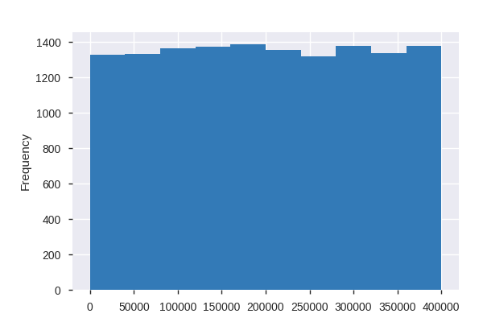

**Common Values**

| Value | Count | Frequency (%) |  |
| --- | --- | --- | --- |
| 364542 | 1 | 0.0% |  |
| 346263 | 1 | 0.0% |  |
| 315606 | 1 | 0.0% |  |
| 371584 | 1 | 0.0% |  |
| 217983 | 1 | 0.0% |  |
| 325758 | 1 | 0.0% |  |
| 64378 | 1 | 0.0% |  |
| 213370 | 1 | 0.0% |  |
| 105334 | 1 | 0.0% |  |
| 349039 | 1 | 0.0% |  |
| Other values (13544) | 13544 | 99.9% |  |

**Extreme Values**

Minimum 5 values

| Value | Count | Frequency (%) |  |
| --- | --- | --- | --- |
| 18 | 1 | 0.0% |  |
| 57 | 1 | 0.0% |  |
| 99 | 1 | 0.0% |  |
| 152 | 1 | 0.0% |  |
| 176 | 1 | 0.0% |  |

Maximum 5 values

| Value | Count | Frequency (%) |  |
| --- | --- | --- | --- |
| 399910 | 1 | 0.0% |  |
| 399938 | 1 | 0.0% |  |
| 399946 | 1 | 0.0% |  |
| 399953 | 1 | 0.0% |  |
| 399995 | 1 | 0.0% |  |

Correlations

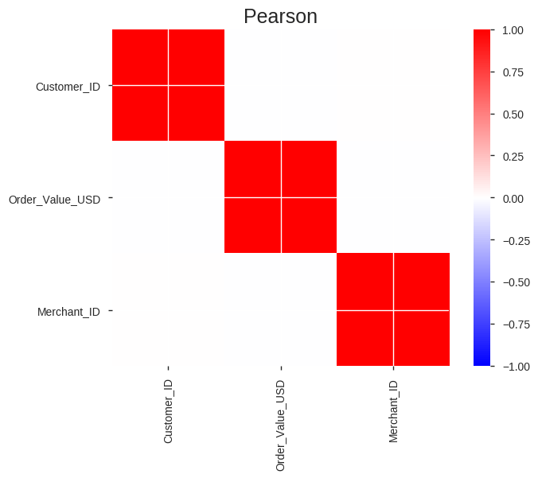

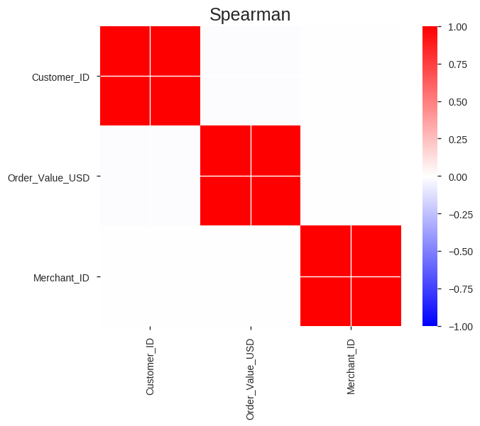

Sample

|  | Customer_ID | Order_ID | Date_of_Order | Order_Value_USD | Order_Source | Order_Payment_Method | Merchant_ID |
| --- | --- | --- | --- | --- | --- | --- | --- |
| 0 | 157068 | a032de091f51 | 2018-03-09 09:09:42 | 60 | SEO | Credit Card | 53637 |
| 1 | 112534 | 0d563f0606d6 | 2018-06-13 20:11:19 | 28 | SEO | Credit Card | 243517 |
| 2 | 148774 | 18fb0fa888b6 | 2018-04-14 04:19:36 | 75 | Ads | Debit Card | 343640 |
| 3 | 114528 | ed1eb920d721 | 2018-04-01 13:55:44 | 98 | SEO | Credit Card | 69889 |
| 4 | 120940 | 313dcf962627 | 2018-05-25 02:08:18 | 35 | SEO | Credit Card | 125706 |

```python
pandas_profiling.ProfileReport(test_order)
```

Overview

Dataset info

| Number of variables | 7 |
| --- | --- |
| Number of observations | 13554 |
| Total Missing (%) | 0.0% |
| Total size in memory | 741.4 KiB |
| Average record size in memory | 56.0 B |

Variables types

| Numeric | 2 |
| --- | --- |
| Categorical | 3 |
| Boolean | 0 |
| Date | 0 |
| Text (Unique) | 1 |
| Rejected | 1 |
| Unsupported | 0 |

Warnings

- `Ecommerce_Provider_ID` has constant value 1746213 Rejected

- `Registered_Device_ID` has a high cardinality: 13213 distinct values Warning

- `IP_Address` has a high cardinality: 13251 distinct values Warning

Variables

Ecommerce_Provider_ID  
Constant

*This variable is constant and should be ignored for analysis*

| Constant value | 1746213 |
| --- | --- |

Merchant_ID  
Numeric

| Distinct count | 13554 |
| --- | --- |
| Unique (%) | 100.0% |
| Missing (%) | 0.0% |
| Missing (n) | 0 |
| Infinite (%) | 0.0% |
| Infinite (n) | 0 |

| Mean | 200440 |
| --- | --- |
| Minimum | 18 |
| Maximum | 399995 |
| Zeros (%) | 0.0% |

Toggle details

**Statistics**

Quantile statistics

| Minimum | 18 |
| --- | --- |
| 5-th percentile | 20558 |
| Q1 | 101690 |
| Median | 199680 |
| Q3 | 300110 |
| 95-th percentile | 379880 |
| Maximum | 399995 |
| Range | 399977 |
| Interquartile range | 198430 |

Descriptive statistics

| Standard deviation | 115070 |
| --- | --- |
| Coef of variation | 0.57408 |
| Kurtosis | -1.1933 |
| Mean | 200440 |
| MAD | 99569 |
| Skewness | 0.0016123 |
| Sum | 2716725659 |
| Variance | 13240000000 |
| Memory size | 106.0 KiB |

**Histogram**

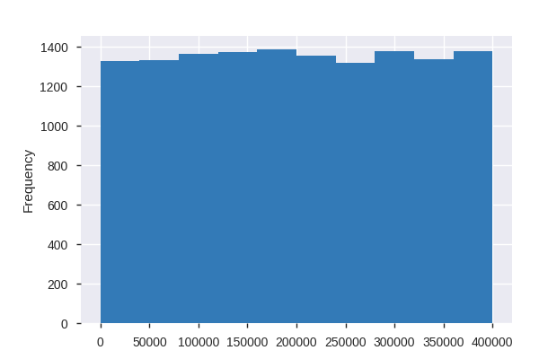

**Common Values**

| Value | Count | Frequency (%) |  |
| --- | --- | --- | --- |
| 364542 | 1 | 0.0% |  |
| 346263 | 1 | 0.0% |  |
| 315606 | 1 | 0.0% |  |
| 371584 | 1 | 0.0% |  |
| 217983 | 1 | 0.0% |  |
| 325758 | 1 | 0.0% |  |
| 64378 | 1 | 0.0% |  |
| 213370 | 1 | 0.0% |  |
| 105334 | 1 | 0.0% |  |
| 349039 | 1 | 0.0% |  |
| Other values (13544) | 13544 | 99.9% |  |

**Extreme Values**

Minimum 5 values

| Value | Count | Frequency (%) |  |
| --- | --- | --- | --- |
| 18 | 1 | 0.0% |  |
| 57 | 1 | 0.0% |  |
| 99 | 1 | 0.0% |  |
| 152 | 1 | 0.0% |  |
| 176 | 1 | 0.0% |  |

Maximum 5 values

| Value | Count | Frequency (%) |  |
| --- | --- | --- | --- |
| 399910 | 1 | 0.0% |  |
| 399938 | 1 | 0.0% |  |
| 399946 | 1 | 0.0% |  |
| 399953 | 1 | 0.0% |  |
| 399995 | 1 | 0.0% |  |

Merchant_Registration_Date  
Categorical, Unique

| First 3 values |
| --- |
| 2018-04-02 23:31:14 |
| 2018-06-22 03:26:31 |
| 2018-01-31 04:11:56 |

| Last 3 values |
| --- |
| 2018-06-11 17:03:34 |
| 2018-04-16 21:21:28 |
| 2018-05-16 04:50:39 |

Toggle details

First 10 values

| Value | Count | Frequency (%) |  |
| --- | --- | --- | --- |
| 2018-01-01 00:00:49 | 1 | 0.0% |  |
| 2018-01-01 00:12:19 | 1 | 0.0% |  |
| 2018-01-01 00:21:35 | 1 | 0.0% |  |
| 2018-01-01 00:44:17 | 1 | 0.0% |  |
| 2018-01-01 00:44:21 | 1 | 0.0% |  |

Last 10 values

| Value | Count | Frequency (%) |  |
| --- | --- | --- | --- |
| 2018-08-18 03:39:05 | 1 | 0.0% |  |
| 2018-08-18 03:49:23 | 1 | 0.0% |  |
| 2018-08-18 03:54:17 | 1 | 0.0% |  |
| 2018-08-18 04:31:58 | 1 | 0.0% |  |
| 2018-08-18 04:37:34 | 1 | 0.0% |  |

Registered_Device_ID  
Categorical

| Distinct count | 13213 |
| --- | --- |
| Unique (%) | 97.5% |
| Missing (%) | 0.0% |
| Missing (n) | 0 |

| XVCSFPAHTBYQC | 5 |
| --- | --- |
| FLXXWDQLYAVLL | 4 |
| KTYUKRGBBATWE | 4 |
| Other values (13210) | 13541 |

Toggle details

| Value | Count | Frequency (%) |  |
| --- | --- | --- | --- |
| XVCSFPAHTBYQC | 5 | 0.0% |  |
| FLXXWDQLYAVLL | 4 | 0.0% |  |
| KTYUKRGBBATWE | 4 | 0.0% |  |
| QYPMINABXZDZD | 4 | 0.0% |  |
| EWIYVSIMWYXYX | 4 | 0.0% |  |
| LVCLKTTFKBAFY | 4 | 0.0% |  |
| SSJNDVNOUTLWP | 4 | 0.0% |  |
| AGUDNVRTBIAIH | 4 | 0.0% |  |
| ZTJIBHPPRNYCJ | 4 | 0.0% |  |
| PSPCRELJUMKJL | 4 | 0.0% |  |
| Other values (13203) | 13513 | 99.7% |  |

Gender  
Categorical

| Distinct count | 2 |
| --- | --- |
| Unique (%) | 0.0% |
| Missing (%) | 0.0% |
| Missing (n) | 0 |

| M | 7937 |
| --- | --- |
| F | 5617 |

Toggle details

| Value | Count | Frequency (%) |  |
| --- | --- | --- | --- |
| M | 7937 | 58.6% |  |
| F | 5617 | 41.4% |  |

Age  
Numeric

| Distinct count | 51 |
| --- | --- |
| Unique (%) | 0.4% |
| Missing (%) | 0.0% |
| Missing (n) | 0 |
| Infinite (%) | 0.0% |
| Infinite (n) | 0 |

| Mean | 33.159 |
| --- | --- |
| Minimum | 18 |
| Maximum | 76 |
| Zeros (%) | 0.0% |

Toggle details

**Statistics**

Quantile statistics

| Minimum | 18 |
| --- | --- |
| 5-th percentile | 20 |
| Q1 | 27 |
| Median | 33 |
| Q3 | 39 |
| 95-th percentile | 48 |
| Maximum | 76 |
| Range | 58 |
| Interquartile range | 12 |

Descriptive statistics

| Standard deviation | 8.5986 |
| --- | --- |
| Coef of variation | 0.25931 |
| Kurtosis | -0.16661 |
| Mean | 33.159 |
| MAD | 6.9947 |
| Skewness | 0.42039 |
| Sum | 449442 |
| Variance | 73.935 |
| Memory size | 106.0 KiB |

**Histogram**

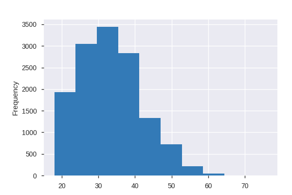

**Common Values**

| Value | Count | Frequency (%) |  |
| --- | --- | --- | --- |
| 32 | 656 | 4.8% |  |
| 33 | 601 | 4.4% |  |
| 31 | 577 | 4.3% |  |
| 29 | 564 | 4.2% |  |
| 30 | 543 | 4.0% |  |
| 28 | 538 | 4.0% |  |
| 34 | 535 | 3.9% |  |
| 27 | 532 | 3.9% |  |
| 37 | 529 | 3.9% |  |
| 35 | 528 | 3.9% |  |
| Other values (41) | 7951 | 58.7% |  |

**Extreme Values**

Minimum 5 values

| Value | Count | Frequency (%) |  |
| --- | --- | --- | --- |
| 18 | 221 | 1.6% |  |
| 19 | 265 | 2.0% |  |
| 20 | 297 | 2.2% |  |
| 21 | 340 | 2.5% |  |
| 22 | 399 | 2.9% |  |

Maximum 5 values

| Value | Count | Frequency (%) |  |
| --- | --- | --- | --- |
| 64 | 4 | 0.0% |  |
| 65 | 3 | 0.0% |  |
| 68 | 1 | 0.0% |  |
| 71 | 1 | 0.0% |  |
| 76 | 1 | 0.0% |  |

IP_Address  
Categorical

| Distinct count | 13251 |
| --- | --- |
| Unique (%) | 97.8% |
| Missing (%) | 0.0% |
| Missing (n) | 0 |

| 34.85.253.200 | 5 |
| --- | --- |
| 8.38.56.35 | 4 |
| 30.214.26.168 | 4 |
| Other values (13248) | 13541 |

Toggle details

| Value | Count | Frequency (%) |  |
| --- | --- | --- | --- |
| 34.85.253.200 | 5 | 0.0% |  |
| 8.38.56.35 | 4 | 0.0% |  |
| 30.214.26.168 | 4 | 0.0% |  |
| 54.36.38.29 | 4 | 0.0% |  |
| 244.97.28.107 | 4 | 0.0% |  |
| 56.35.202.156 | 4 | 0.0% |  |
| 13.100.209.201 | 4 | 0.0% |  |
| 110.151.252.131 | 4 | 0.0% |  |
| 39.6.21.99 | 4 | 0.0% |  |
| 120.236.62.213 | 4 | 0.0% |  |
| Other values (13241) | 13513 | 99.7% |  |

Correlations

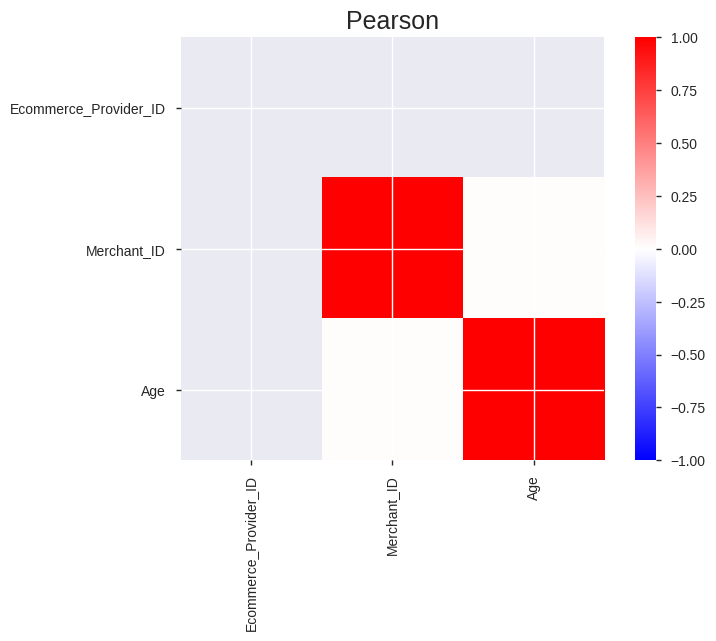

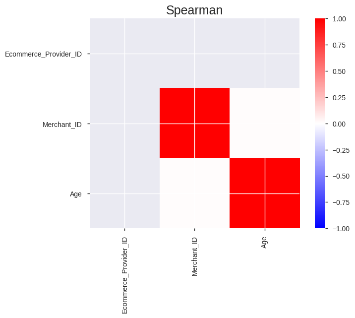

Sample

|  | Ecommerce_Provider_ID | Merchant_ID | Merchant_Registration_Date | Registered_Device_ID | Gender | Age | IP_Address |
| --- | --- | --- | --- | --- | --- | --- | --- |
| 0 | 1746213 | 53637 | 2018-02-11 20:50:29 | PTMLBENYMQCTV | F | 40 | 134.162.124.62 |
| 1 | 1746213 | 243517 | 2018-04-06 13:19:39 | HMCLDZUZPWZRR | M | 39 | 152.76.98.87 |
| 2 | 1746213 | 343640 | 2018-01-12 16:47:49 | VLGSMAPXISSEJ | M | 23 | 31.202.3.255 |
| 3 | 1746213 | 69889 | 2018-02-19 21:58:52 | ZINHISBBOKQXT | M | 34 | 12.242.168.185 |
| 4 | 1746213 | 125706 | 2018-05-17 15:50:19 | WFKEAOTPHTYEO | M | 20 | 26.61.210.47 |

```python
pandas_profiling.ProfileReport(test_merchant)
```

Loading test datas

```python
train_order.head()
```

|  | Customer_ID | Order_ID | Date_of_Order | Order_Value_USD | Order_Source | Order_Payment_Method | Merchant_ID |
| --- | --- | --- | --- | --- | --- | --- | --- |
| 0 | 126221 | 37cea9512f8d | 2018-04-29 16:39:26 | 148 | Direct | Credit Card | 124231 |
| 1 | 115471 | 09f12e6efde2 | 2018-06-16 17:05:40 | 145 | SEO | Credit Card | 136178 |
| 2 | 151786 | 4e69e956e159 | 2018-10-26 18:00:46 | 62 | Ads | Internet Banking | 198611 |
| 3 | 140456 | 663443aaeb82 | 2018-12-12 05:41:52 | 28 | SEO | Debit Card | 127993 |
| 4 | 114721 | 99258810c121 | 2018-09-20 11:06:10 | 70 | Ads | Credit Card | 250146 |

```python
train_merchant.head()
```

|  | Ecommerce_Provider_ID | Merchant_ID | Merchant_Registration_Date | Registered_Device_ID | Gender | Age | IP_Address |
| --- | --- | --- | --- | --- | --- | --- | --- |
| 0 | 1746213 | 50448 | 2018-05-01 21:15:11 | VATQMMZTVOZUT | F | 39 | 48.151.136.76 |
| 1 | 1746213 | 338754 | 2018-04-14 10:13:00 | LJCILLBRQZNKS | M | 35 | 94.9.145.169 |
| 2 | 1746213 | 291127 | 2018-06-20 07:44:22 | JFVHSUGKDAYZV | F | 40 | 58.94.157.121 |
| 3 | 1746213 | 319919 | 2018-06-27 01:41:39 | WFRXMPLQYXRMY | M | 37 | 193.187.41.186 |
| 4 | 1746213 | 195911 | 2018-01-05 00:55:41 | GGHKWMSWHCMID | F | 27 | 125.96.20.172 |

```python
traindata.head()
```

|  | Merchant_ID | Fraudster |
| --- | --- | --- |
| 0 | 221592 | 0 |
| 1 | 316935 | 1 |
| 2 | 38454 | 1 |
| 3 | 214437 | 1 |
| 4 | 296240 | 1 |

```python
test_order.head()
```

|  | Customer_ID | Order_ID | Date_of_Order | Order_Value_USD | Order_Source | Order_Payment_Method | Merchant_ID |
| --- | --- | --- | --- | --- | --- | --- | --- |
| 0 | 157068 | a032de091f51 | 2018-03-09 09:09:42 | 60 | SEO | Credit Card | 53637 |
| 1 | 112534 | 0d563f0606d6 | 2018-06-13 20:11:19 | 28 | SEO | Credit Card | 243517 |
| 2 | 148774 | 18fb0fa888b6 | 2018-04-14 04:19:36 | 75 | Ads | Debit Card | 343640 |
| 3 | 114528 | ed1eb920d721 | 2018-04-01 13:55:44 | 98 | SEO | Credit Card | 69889 |
| 4 | 120940 | 313dcf962627 | 2018-05-25 02:08:18 | 35 | SEO | Credit Card | 125706 |

```python
test_merchant.head()
```

|  | Ecommerce_Provider_ID | Merchant_ID | Merchant_Registration_Date | Registered_Device_ID | Gender | Age | IP_Address |
| --- | --- | --- | --- | --- | --- | --- | --- |
| 0 | 1746213 | 53637 | 2018-02-11 20:50:29 | PTMLBENYMQCTV | F | 40 | 134.162.124.62 |
| 1 | 1746213 | 243517 | 2018-04-06 13:19:39 | HMCLDZUZPWZRR | M | 39 | 152.76.98.87 |
| 2 | 1746213 | 343640 | 2018-01-12 16:47:49 | VLGSMAPXISSEJ | M | 23 | 31.202.3.255 |
| 3 | 1746213 | 69889 | 2018-02-19 21:58:52 | ZINHISBBOKQXT | M | 34 | 12.242.168.185 |
| 4 | 1746213 | 125706 | 2018-05-17 15:50:19 | WFKEAOTPHTYEO | M | 20 | 26.61.210.47 |

```python
#Merging the datasets: Test and Train
merged_train=train_order.merge(train_merchant, on="Merchant_ID").merge(traindata, on="Merchant_ID")
merged_test=test_order.merge(test_merchant, on="Merchant_ID")
```

```python
merged_train.head(2)
```

|  | Customer_ID | Order_ID | Date_of_Order | Order_Value_USD | Order_Source | Order_Payment_Method | Merchant_ID | Ecommerce_Provider_ID | Merchant_Registration_Date | Registered_Device_ID | Gender | Age | IP_Address | Fraudster |
| --- | --- | --- | --- | --- | --- | --- | --- | --- | --- | --- | --- | --- | --- | --- |
| 0 | 126221 | 37cea9512f8d | 2018-04-29 16:39:26 | 148 | Direct | Credit Card | 124231 | 1746213 | 2018-04-19 00:48:20 | BEJVAJMFDUVOQ | M | 30 | 37.113.112.143 | 0 |
| 1 | 115471 | 09f12e6efde2 | 2018-06-16 17:05:40 | 145 | SEO | Credit Card | 136178 | 1746213 | 2018-05-15 23:30:37 | GFHLOGZGFHNYH | F | 20 | 190.255.172.133 | 0 |

```python
merged_test.head(2)
```

|  | Customer_ID | Order_ID | Date_of_Order | Order_Value_USD | Order_Source | Order_Payment_Method | Merchant_ID | Ecommerce_Provider_ID | Merchant_Registration_Date | Registered_Device_ID | Gender | Age | IP_Address |
| --- | --- | --- | --- | --- | --- | --- | --- | --- | --- | --- | --- | --- | --- |
| 0 | 157068 | a032de091f51 | 2018-03-09 09:09:42 | 60 | SEO | Credit Card | 53637 | 1746213 | 2018-02-11 20:50:29 | PTMLBENYMQCTV | F | 40 | 134.162.124.62 |
| 1 | 112534 | 0d563f0606d6 | 2018-06-13 20:11:19 | 28 | SEO | Credit Card | 243517 | 1746213 | 2018-04-06 13:19:39 | HMCLDZUZPWZRR | M | 39 | 152.76.98.87 |

```python
merged_train['Fraudster'].value_counts()
```

```
0    49188
1     5025
Name: Fraudster, dtype: int64
```

```python
merged_train.sample(2)
```

|  | Customer_ID | Order_ID | Date_of_Order | Order_Value_USD | Order_Source | Order_Payment_Method | Merchant_ID | Ecommerce_Provider_ID | Merchant_Registration_Date | Registered_Device_ID | Gender | Age | IP_Address | Fraudster |
| --- | --- | --- | --- | --- | --- | --- | --- | --- | --- | --- | --- | --- | --- | --- |
| 49975 | 155120 | 0a78ea9afa08 | 2018-08-23 19:19:57 | 150 | Ads | Internet Banking | 284823 | 1746213 | 2018-06-30 12:10:07 | GEUCHLNIXLGIU | M | 43 | 64.251.42.211 | 0 |
| 32639 | 154429 | 75bd0eacb03e | 2018-04-20 08:39:37 | 32 | Direct | Debit Card | 166548 | 1746213 | 2018-04-13 21:05:51 | NDXJKONYCODFG | F | 33 | 136.125.196.249 | 0 |

```python
merged_test.sample(2)
```

|  | Customer_ID | Order_ID | Date_of_Order | Order_Value_USD | Order_Source | Order_Payment_Method | Merchant_ID | Ecommerce_Provider_ID | Merchant_Registration_Date | Registered_Device_ID | Gender | Age | IP_Address |
| --- | --- | --- | --- | --- | --- | --- | --- | --- | --- | --- | --- | --- | --- |
| 11049 | 123042 | ed1bd10993fc | 2018-01-04 03:01:12 | 75 | Ads | Credit Card | 337490 | 1746213 | 2018-01-02 03:01:11 | TFFVRDMIAXPGK | M | 30 | 19.90.248.214 |
| 6704 | 122285 | 03cab0ee4145 | 2018-08-02 09:08:33 | 48 | SEO | Internet Banking | 82302 | 1746213 | 2018-04-15 12:41:46 | ZRBQWEAVABMML | F | 23 | 59.233.249.86 |

Installing the package to get the IP address to match with the countries

```python
pip install maxminddb-geolite2
```

```python
from geolite2 import geolite2

def get_continent(ip):
    try:
        x = geo.get(ip)
    except ValueError:
        return pd.np.nan
    try:
        return x['continent']['names']['en'] if x else pd.np.nan
    except KeyError:
        return pd.np.nan

geo = geolite2.reader()
# IP's for testing: http://upd.emule-security.org/ipfilter.zip
#x = pd.read_csv(r'D:\download\ipfilter.zip',usecols=[0], sep='\s*\-\s*',header=None, names=['ip'])

# get unique IPs
unique_ips = merged_train["IP_Address"].unique()
# make series out of it
unique_ips = pd.Series(unique_ips, index = unique_ips)
# map IP --> country
merged_train['Continent'] = merged_train['IP_Address'].map(unique_ips.apply(get_continent))

geolite2.close()
```

```
0    90.731005
1     9.268995
Name: Fraudster, dtype: float64
```

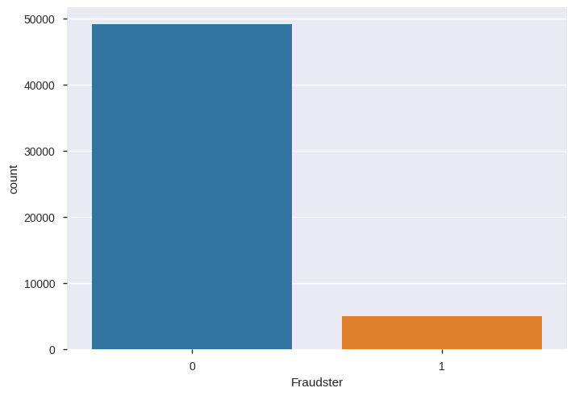

```python
merged_train['Fraudster'].value_counts()
sns.countplot(x='Fraudster',data=merged_train)
plt.show()
(merged_train["Fraudster"].value_counts()/merged_train.shape[0]*100)
```

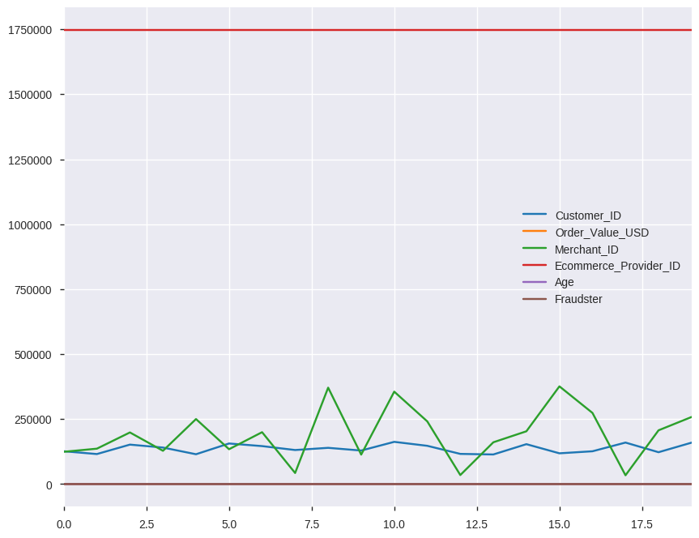

```python
# Line plot
merged_train.head(20).plot(kind='line', figsize=(10,8))
plt.show()
```

```python
merged_train.sample(10)
```

|  | Customer_ID | Order_ID | Date_of_Order | Order_Value_USD | Order_Source | Order_Payment_Method | Merchant_ID | Ecommerce_Provider_ID | Merchant_Registration_Date | Registered_Device_ID | Gender | Age | IP_Address | Fraudster | Continent |
| --- | --- | --- | --- | --- | --- | --- | --- | --- | --- | --- | --- | --- | --- | --- | --- |
| 35757 | 116776 | 0d639d10a755 | 2018-04-12 03:58:14 | 65 | Ads | Debit Card | 220031 | 1746213 | 2018-03-19 09:26:00 | ZCXMUWJQCPSRA | M | 25 | 78.71.220.89 | 0 | Europe |
| 43350 | 154016 | c293f37b3433 | 2018-07-21 08:01:53 | 65 | Ads | Credit Card | 39272 | 1746213 | 2018-06-22 02:59:06 | EKOFRVSLJTFQZ | M | 40 | 86.89.241.132 | 0 | Europe |
| 50141 | 123209 | 3b7bd41dd6cf | 2018-04-05 23:49:23 | 28 | Ads | E-wallet | 282677 | 1746213 | 2018-02-27 19:56:04 | ONHHEXJBKNDAP | M | 25 | 83.33.195.86 | 0 | Europe |
| 33376 | 162771 | a8ae764b7c0e | 2018-03-31 08:21:53 | 28 | SEO | Internet Banking | 43114 | 1746213 | 2018-02-10 04:35:49 | NMAAVLCGYVTET | F | 27 | 35.82.210.77 | 0 | North America |
| 9872 | 163294 | 105e0f23b9fb | 2018-09-06 12:55:13 | 35 | Ads | Credit Card | 33545 | 1746213 | 2018-05-29 04:51:31 | EBKOGXGJYODPW | M | 48 | 86.132.239.191 | 0 | Europe |
| 40592 | 120807 | dde278adf1bb | 2018-03-04 19:24:09 | 25 | SEO | Credit Card | 18236 | 1746213 | 2018-01-14 17:32:55 | MKXHCDRVXMEVV | F | 34 | 144.132.94.12 | 0 | Oceania |
| 45449 | 143656 | d0cdbd3eba28 | 2018-01-08 01:37:04 | 25 | SEO | E-wallet | 340146 | 1746213 | 2018-01-06 01:37:03 | TYFYSQMGCCDIG | M | 52 | 44.221.130.127 | 1 | North America |
| 29362 | 130553 | d3f62b77dc37 | 2018-05-13 03:03:26 | 95 | Direct | Credit Card | 270796 | 1746213 | 2018-05-04 06:18:19 | LIBYHKENAOHSV | F | 42 | 14.50.10.231 | 0 | Asia |
| 53701 | 117364 | 9c9c4bb155ce | 2018-06-07 03:46:49 | 148 | Ads | Credit Card | 42930 | 1746213 | 2018-02-27 11:40:53 | OGTGLBGBHCUJE | M | 39 | 11.125.50.45 | 0 | North America |
| 8351 | 143124 | 68811c07ed98 | 2018-09-11 16:12:15 | 32 | Ads | Debit Card | 352704 | 1746213 | 2018-07-16 13:39:22 | TFCSEEUSCWBFK | F | 32 | 156.25.106.215 | 0 | Europe |

```python
merged_train['Continent'].isnull().sum()
```

```
7751
```

```python
from geolite2 import geolite2

def get_continent(ip):
    try:
        x = geo.get(ip)
    except ValueError:
        return pd.np.nan
    try:
        return x['continent']['names']['en'] if x else pd.np.nan
    except KeyError:
        return pd.np.nan

geo = geolite2.reader()

# IP's for testing: http://upd.emule-security.org/ipfilter.zip
#x = pd.read_csv(r'D:\download\ipfilter.zip',usecols=[0], sep='\s*\-\s*',header=None, names=['ip'])

# get unique IPs
unique_ips = merged_test["IP_Address"].unique()
# make series out of it
unique_ips = pd.Series(unique_ips, index = unique_ips)
# map IP --> country
merged_test['Continent'] = merged_test['IP_Address'].map(unique_ips.apply(get_continent))

geolite2.close()
```

```python
merged_train['Continent'].fillna('Unknown', inplace=True)
```

```python
merged_train.sample(2)
```

|  | Customer_ID | Order_ID | Date_of_Order | Order_Value_USD | Order_Source | Order_Payment_Method | Merchant_ID | Ecommerce_Provider_ID | Merchant_Registration_Date | Registered_Device_ID | Gender | Age | IP_Address | Fraudster | Continent |
| --- | --- | --- | --- | --- | --- | --- | --- | --- | --- | --- | --- | --- | --- | --- | --- |
| 28399 | 120859 | 3d7db2eea8f2 | 2018-04-15 18:13:57 | 38 | Ads | E-wallet | 315633 | 1746213 | 2018-02-06 13:59:39 | TRONEJNUHUAJA | M | 36 | 2.145.229.145 | 0 | Asia |
| 34215 | 139840 | 59b994c72368 | 2018-09-09 08:25:22 | 62 | SEO | Debit Card | 223912 | 1746213 | 2018-06-01 01:26:33 | CRILRGXIDCJJP | M | 30 | 139.248.50.115 | 0 | North America |

```python
merged_train['Continent'].fillna('Unknown', inplace=True)
```

```python
merged_test['Continent'].isnull().sum()
```

```
1967
```

```python
merged_test['Continent'].fillna('Unknown', inplace=True)
```

```python
conti = pd.crosstab(merged_train.Fraudster, merged_train.Continent)
```

```python
conti
```

| Continent Fraudster | Africa | Asia | Europe | North America | Oceania | South America | Unknown |
| --- | --- | --- | --- | --- | --- | --- | --- |
| 0 | 585 | 10371 | 8637 | 20123 | 711 | 1661 | 7100 |
| 1 | 81 | 1062 | 849 | 2126 | 67 | 189 | 651 |

#### Feature Engineering

Converting Date_of_order and Merchand_registration_date type as datetime64 for both train and test data

```python
merged_train["Date_of_Order"] = merged_train["Date_of_Order"].astype('datetime64[ns]')
merged_train["Merchant_Registration_Date"] = merged_train["Merchant_Registration_Date"].astype('datetime64[ns]')
```

```python
merged_test["Date_of_Order"] = merged_test["Date_of_Order"].astype('datetime64[ns]')
merged_test["Merchant_Registration_Date"] = merged_test["Merchant_Registration_Date"].astype('datetime64[ns]')
```

```python
merged_train.head(5)
```

|  | Customer_ID | Order_ID | Date_of_Order | Order_Value_USD | Order_Source | Order_Payment_Method | Merchant_ID | Ecommerce_Provider_ID | Merchant_Registration_Date | Registered_Device_ID | Gender | Age | IP_Address | Fraudster | Continent |
| --- | --- | --- | --- | --- | --- | --- | --- | --- | --- | --- | --- | --- | --- | --- | --- |
| 0 | 126221 | 37cea9512f8d | 2018-04-29 16:39:26 | 148 | Direct | Credit Card | 124231 | 1746213 | 2018-04-19 00:48:20 | BEJVAJMFDUVOQ | M | 30 | 37.113.112.143 | 0 | Europe |
| 1 | 115471 | 09f12e6efde2 | 2018-06-16 17:05:40 | 145 | SEO | Credit Card | 136178 | 1746213 | 2018-05-15 23:30:37 | GFHLOGZGFHNYH | F | 20 | 190.255.172.133 | 0 | South America |
| 2 | 151786 | 4e69e956e159 | 2018-10-26 18:00:46 | 62 | Ads | Internet Banking | 198611 | 1746213 | 2018-08-11 04:12:15 | MTELXLHIBWHGI | F | 46 | 130.243.149.190 | 1 | Europe |
| 3 | 140456 | 663443aaeb82 | 2018-12-12 05:41:52 | 28 | SEO | Debit Card | 127993 | 1746213 | 2018-08-17 01:52:14 | ZPJCMOXVRXVJF | M | 37 | 48.250.147.203 | 0 | North America |
| 4 | 114721 | 99258810c121 | 2018-09-20 11:06:10 | 70 | Ads | Credit Card | 250146 | 1746213 | 2018-05-26 11:58:33 | NVDDVXILKZTVO | F | 26 | 212.167.41.153 | 0 | Europe |

```python
merged_test.head(5)
```

|  | Customer_ID | Order_ID | Date_of_Order | Order_Value_USD | Order_Source | Order_Payment_Method | Merchant_ID | Ecommerce_Provider_ID | Merchant_Registration_Date | Registered_Device_ID | Gender | Age | IP_Address | Continent |
| --- | --- | --- | --- | --- | --- | --- | --- | --- | --- | --- | --- | --- | --- | --- |
| 0 | 157068 | a032de091f51 | 2018-03-09 09:09:42 | 60 | SEO | Credit Card | 53637 | 1746213 | 2018-02-11 20:50:29 | PTMLBENYMQCTV | F | 40 | 134.162.124.62 | North America |
| 1 | 112534 | 0d563f0606d6 | 2018-06-13 20:11:19 | 28 | SEO | Credit Card | 243517 | 1746213 | 2018-04-06 13:19:39 | HMCLDZUZPWZRR | M | 39 | 152.76.98.87 | Oceania |
| 2 | 148774 | 18fb0fa888b6 | 2018-04-14 04:19:36 | 75 | Ads | Debit Card | 343640 | 1746213 | 2018-01-12 16:47:49 | VLGSMAPXISSEJ | M | 23 | 31.202.3.255 | Europe |
| 3 | 114528 | ed1eb920d721 | 2018-04-01 13:55:44 | 98 | SEO | Credit Card | 69889 | 1746213 | 2018-02-19 21:58:52 | ZINHISBBOKQXT | M | 34 | 12.242.168.185 | North America |
| 4 | 120940 | 313dcf962627 | 2018-05-25 02:08:18 | 35 | SEO | Credit Card | 125706 | 1746213 | 2018-05-17 15:50:19 | WFKEAOTPHTYEO | M | 20 | 26.61.210.47 | North America |

Creating a new_feature Difference_Date by substracting Date_of_order and Merchant_registration_date

```python
merged_train["Difference_Dates"]=(merged_train["Date_of_Order"])- ( merged_train["Merchant_Registration_Date"])
merged_test["Difference_Dates"]=(merged_test["Date_of_Order"])- ( merged_test["Merchant_Registration_Date"])
```

```python
merged_train.head()
```

|  | Customer_ID | Order_ID | Date_of_Order | Order_Value_USD | Order_Source | Order_Payment_Method | Merchant_ID | Ecommerce_Provider_ID | Merchant_Registration_Date | Registered_Device_ID | Gender | Age | IP_Address | Fraudster | Continent | Difference_Dates |
| --- | --- | --- | --- | --- | --- | --- | --- | --- | --- | --- | --- | --- | --- | --- | --- | --- |
| 0 | 126221 | 37cea9512f8d | 2018-04-29 16:39:26 | 148 | Direct | Credit Card | 124231 | 1746213 | 2018-04-19 00:48:20 | BEJVAJMFDUVOQ | M | 30 | 37.113.112.143 | 0 | Europe | 10 days 15:51:06 |
| 1 | 115471 | 09f12e6efde2 | 2018-06-16 17:05:40 | 145 | SEO | Credit Card | 136178 | 1746213 | 2018-05-15 23:30:37 | GFHLOGZGFHNYH | F | 20 | 190.255.172.133 | 0 | South America | 31 days 17:35:03 |
| 2 | 151786 | 4e69e956e159 | 2018-10-26 18:00:46 | 62 | Ads | Internet Banking | 198611 | 1746213 | 2018-08-11 04:12:15 | MTELXLHIBWHGI | F | 46 | 130.243.149.190 | 1 | Europe | 76 days 13:48:31 |
| 3 | 140456 | 663443aaeb82 | 2018-12-12 05:41:52 | 28 | SEO | Debit Card | 127993 | 1746213 | 2018-08-17 01:52:14 | ZPJCMOXVRXVJF | M | 37 | 48.250.147.203 | 0 | North America | 117 days 03:49:38 |
| 4 | 114721 | 99258810c121 | 2018-09-20 11:06:10 | 70 | Ads | Credit Card | 250146 | 1746213 | 2018-05-26 11:58:33 | NVDDVXILKZTVO | F | 26 | 212.167.41.153 | 0 | Europe | 116 days 23:07:37 |

```python
merged_test.head()
```

|  | Customer_ID | Order_ID | Date_of_Order | Order_Value_USD | Order_Source | Order_Payment_Method | Merchant_ID | Ecommerce_Provider_ID | Merchant_Registration_Date | Registered_Device_ID | Gender | Age | IP_Address | Continent | Difference_Dates |
| --- | --- | --- | --- | --- | --- | --- | --- | --- | --- | --- | --- | --- | --- | --- | --- |
| 0 | 157068 | a032de091f51 | 2018-03-09 09:09:42 | 60 | SEO | Credit Card | 53637 | 1746213 | 2018-02-11 20:50:29 | PTMLBENYMQCTV | F | 40 | 134.162.124.62 | North America | 25 days 12:19:13 |
| 1 | 112534 | 0d563f0606d6 | 2018-06-13 20:11:19 | 28 | SEO | Credit Card | 243517 | 1746213 | 2018-04-06 13:19:39 | HMCLDZUZPWZRR | M | 39 | 152.76.98.87 | Oceania | 68 days 06:51:40 |
| 2 | 148774 | 18fb0fa888b6 | 2018-04-14 04:19:36 | 75 | Ads | Debit Card | 343640 | 1746213 | 2018-01-12 16:47:49 | VLGSMAPXISSEJ | M | 23 | 31.202.3.255 | Europe | 91 days 11:31:47 |
| 3 | 114528 | ed1eb920d721 | 2018-04-01 13:55:44 | 98 | SEO | Credit Card | 69889 | 1746213 | 2018-02-19 21:58:52 | ZINHISBBOKQXT | M | 34 | 12.242.168.185 | North America | 40 days 15:56:52 |
| 4 | 120940 | 313dcf962627 | 2018-05-25 02:08:18 | 35 | SEO | Credit Card | 125706 | 1746213 | 2018-05-17 15:50:19 | WFKEAOTPHTYEO | M | 20 | 26.61.210.47 | North America | 7 days 10:17:59 |

Dividing Difference_dates by day we get the differnce

```python
merged_train["Difference_Dates"]=merged_train["Difference_Dates"]/np.timedelta64(1, "D")
merged_test["Difference_Dates"]=merged_test["Difference_Dates"]/np.timedelta64(1, "D")
```

```python
merged_train.head()
```

|  | Customer_ID | Order_ID | Date_of_Order | Order_Value_USD | Order_Source | Order_Payment_Method | Merchant_ID | Ecommerce_Provider_ID | Merchant_Registration_Date | Registered_Device_ID | Gender | Age | IP_Address | Fraudster | Continent | Difference_Dates |
| --- | --- | --- | --- | --- | --- | --- | --- | --- | --- | --- | --- | --- | --- | --- | --- | --- |
| 0 | 126221 | 37cea9512f8d | 2018-04-29 16:39:26 | 148 | Direct | Credit Card | 124231 | 1746213 | 2018-04-19 00:48:20 | BEJVAJMFDUVOQ | M | 30 | 37.113.112.143 | 0 | Europe | 10.660486 |
| 1 | 115471 | 09f12e6efde2 | 2018-06-16 17:05:40 | 145 | SEO | Credit Card | 136178 | 1746213 | 2018-05-15 23:30:37 | GFHLOGZGFHNYH | F | 20 | 190.255.172.133 | 0 | South America | 31.732674 |
| 2 | 151786 | 4e69e956e159 | 2018-10-26 18:00:46 | 62 | Ads | Internet Banking | 198611 | 1746213 | 2018-08-11 04:12:15 | MTELXLHIBWHGI | F | 46 | 130.243.149.190 | 1 | Europe | 76.575359 |
| 3 | 140456 | 663443aaeb82 | 2018-12-12 05:41:52 | 28 | SEO | Debit Card | 127993 | 1746213 | 2018-08-17 01:52:14 | ZPJCMOXVRXVJF | M | 37 | 48.250.147.203 | 0 | North America | 117.159468 |
| 4 | 114721 | 99258810c121 | 2018-09-20 11:06:10 | 70 | Ads | Credit Card | 250146 | 1746213 | 2018-05-26 11:58:33 | NVDDVXILKZTVO | F | 26 | 212.167.41.153 | 0 | Europe | 116.963623 |

```python
merged_test.head()
```

|  | Customer_ID | Order_ID | Date_of_Order | Order_Value_USD | Order_Source | Order_Payment_Method | Merchant_ID | Ecommerce_Provider_ID | Merchant_Registration_Date | Registered_Device_ID | Gender | Age | IP_Address | Continent | Difference_Dates |
| --- | --- | --- | --- | --- | --- | --- | --- | --- | --- | --- | --- | --- | --- | --- | --- |
| 0 | 157068 | a032de091f51 | 2018-03-09 09:09:42 | 60 | SEO | Credit Card | 53637 | 1746213 | 2018-02-11 20:50:29 | PTMLBENYMQCTV | F | 40 | 134.162.124.62 | North America | 25.513345 |
| 1 | 112534 | 0d563f0606d6 | 2018-06-13 20:11:19 | 28 | SEO | Credit Card | 243517 | 1746213 | 2018-04-06 13:19:39 | HMCLDZUZPWZRR | M | 39 | 152.76.98.87 | Oceania | 68.285880 |
| 2 | 148774 | 18fb0fa888b6 | 2018-04-14 04:19:36 | 75 | Ads | Debit Card | 343640 | 1746213 | 2018-01-12 16:47:49 | VLGSMAPXISSEJ | M | 23 | 31.202.3.255 | Europe | 91.480405 |
| 3 | 114528 | ed1eb920d721 | 2018-04-01 13:55:44 | 98 | SEO | Credit Card | 69889 | 1746213 | 2018-02-19 21:58:52 | ZINHISBBOKQXT | M | 34 | 12.242.168.185 | North America | 40.664491 |
| 4 | 120940 | 313dcf962627 | 2018-05-25 02:08:18 | 35 | SEO | Credit Card | 125706 | 1746213 | 2018-05-17 15:50:19 | WFKEAOTPHTYEO | M | 20 | 26.61.210.47 | North America | 7.429155 |

```python
merged_train[merged_train["Difference_Dates"]<=0].Fraudster.value_counts()
```

```
Series([], Name: Fraudster, dtype: int64)
```

```python
merged_train.Fraudster.value_counts()
```

```
0    49188
1     5025
Name: Fraudster, dtype: int64
```

```python
train_dev_Id=merged_train['Registered_Device_ID']
test_dev_id=merged_test['Registered_Device_ID']
```

```python
train_dev_Id= pd.DataFrame(train_dev_Id)
test_dev_id=pd.DataFrame(test_dev_id)
```

```python
merged_train['Registered_Device_Count'] = train_dev_Id.apply(lambda x: x.map(x.value_counts()))
merged_test['Registered_Device_Count'] = test_dev_id.apply(lambda x: x.map(x.value_counts()))
```

```python
merged_train.head(10)
```

|  | Customer_ID | Order_ID | Date_of_Order | Order_Value_USD | Order_Source | Order_Payment_Method | Merchant_ID | Ecommerce_Provider_ID | Merchant_Registration_Date | Registered_Device_ID | Gender | Age | IP_Address | Fraudster | Continent | Difference_Dates | Registered_Device_Count |
| --- | --- | --- | --- | --- | --- | --- | --- | --- | --- | --- | --- | --- | --- | --- | --- | --- | --- |
| 0 | 126221 | 37cea9512f8d | 2018-04-29 16:39:26 | 148 | Direct | Credit Card | 124231 | 1746213 | 2018-04-19 00:48:20 | BEJVAJMFDUVOQ | M | 30 | 37.113.112.143 | 0 | Europe | 10.660486 | 1 |
| 1 | 115471 | 09f12e6efde2 | 2018-06-16 17:05:40 | 145 | SEO | Credit Card | 136178 | 1746213 | 2018-05-15 23:30:37 | GFHLOGZGFHNYH | F | 20 | 190.255.172.133 | 0 | South America | 31.732674 | 1 |
| 2 | 151786 | 4e69e956e159 | 2018-10-26 18:00:46 | 62 | Ads | Internet Banking | 198611 | 1746213 | 2018-08-11 04:12:15 | MTELXLHIBWHGI | F | 46 | 130.243.149.190 | 1 | Europe | 76.575359 | 1 |
| 3 | 140456 | 663443aaeb82 | 2018-12-12 05:41:52 | 28 | SEO | Debit Card | 127993 | 1746213 | 2018-08-17 01:52:14 | ZPJCMOXVRXVJF | M | 37 | 48.250.147.203 | 0 | North America | 117.159468 | 1 |
| 4 | 114721 | 99258810c121 | 2018-09-20 11:06:10 | 70 | Ads | Credit Card | 250146 | 1746213 | 2018-05-26 11:58:33 | NVDDVXILKZTVO | F | 26 | 212.167.41.153 | 0 | Europe | 116.963623 | 1 |
| 5 | 156106 | f1e5595ef446 | 2018-05-13 08:20:42 | 100 | Direct | Internet Banking | 134043 | 1746213 | 2018-01-14 04:00:40 | WUTMJNOOMJVPB | M | 22 | 189.20.88.190 | 0 | South America | 119.180579 | 1 |
| 6 | 146054 | 96d864107383 | 2018-03-30 02:47:44 | 65 | SEO | Credit Card | 199582 | 1746213 | 2018-03-06 20:57:39 | FLPWOWXWKIKLY | M | 47 | 12.2.181.60 | 0 | North America | 23.243113 | 1 |
| 7 | 130966 | c26e79192d46 | 2018-08-28 16:48:35 | 140 | SEO | E-wallet | 42529 | 1746213 | 2018-05-06 12:57:03 | SILPRWIQBZENF | F | 31 | 177.217.21.179 | 0 | South America | 114.160787 | 1 |
| 8 | 139404 | 4bbf3902918f | 2018-09-19 08:29:24 | 100 | SEO | Debit Card | 370985 | 1746213 | 2018-06-14 02:11:50 | VBFDELIQZJXKM | F | 21 | 199.131.246.210 | 0 | North America | 97.262199 | 1 |
| 9 | 128964 | 8551ac9908b4 | 2018-01-06 15:16:03 | 45 | Direct | Credit Card | 113335 | 1746213 | 2018-01-04 15:16:02 | GXZWUMERANRMA | M | 38 | 35.163.82.112 | 1 | North America | 2.000012 | 5 |

```python
merged_test.head(10)
```

|  | Customer_ID | Order_ID | Date_of_Order | Order_Value_USD | Order_Source | Order_Payment_Method | Merchant_ID | Ecommerce_Provider_ID | Merchant_Registration_Date | Registered_Device_ID | Gender | Age | IP_Address | Continent | Difference_Dates | Registered_Device_Count |
| --- | --- | --- | --- | --- | --- | --- | --- | --- | --- | --- | --- | --- | --- | --- | --- | --- |
| 0 | 157068 | a032de091f51 | 2018-03-09 09:09:42 | 60 | SEO | Credit Card | 53637 | 1746213 | 2018-02-11 20:50:29 | PTMLBENYMQCTV | F | 40 | 134.162.124.62 | North America | 25.513345 | 1 |
| 1 | 112534 | 0d563f0606d6 | 2018-06-13 20:11:19 | 28 | SEO | Credit Card | 243517 | 1746213 | 2018-04-06 13:19:39 | HMCLDZUZPWZRR | M | 39 | 152.76.98.87 | Oceania | 68.285880 | 1 |
| 2 | 148774 | 18fb0fa888b6 | 2018-04-14 04:19:36 | 75 | Ads | Debit Card | 343640 | 1746213 | 2018-01-12 16:47:49 | VLGSMAPXISSEJ | M | 23 | 31.202.3.255 | Europe | 91.480405 | 1 |
| 3 | 114528 | ed1eb920d721 | 2018-04-01 13:55:44 | 98 | SEO | Credit Card | 69889 | 1746213 | 2018-02-19 21:58:52 | ZINHISBBOKQXT | M | 34 | 12.242.168.185 | North America | 40.664491 | 1 |
| 4 | 120940 | 313dcf962627 | 2018-05-25 02:08:18 | 35 | SEO | Credit Card | 125706 | 1746213 | 2018-05-17 15:50:19 | WFKEAOTPHTYEO | M | 20 | 26.61.210.47 | North America | 7.429155 | 1 |
| 5 | 138132 | 403af6a56bf6 | 2018-03-12 17:49:02 | 45 | Direct | E-wallet | 99740 | 1746213 | 2018-01-14 22:38:00 | QLABSSSYDDVLX | F | 53 | 67.233.208.80 | North America | 56.799329 | 1 |
| 6 | 126307 | 2000c9a7f224 | 2018-01-14 01:04:38 | 125 | Ads | Internet Banking | 286064 | 1746213 | 2018-01-12 01:04:37 | YZUTNBIQUUKJG | M | 28 | 88.120.173.167 | Europe | 2.000012 | 3 |
| 7 | 156600 | 14cef8a72083 | 2018-07-10 21:31:50 | 65 | Ads | Internet Banking | 106848 | 1746213 | 2018-05-19 08:50:04 | QNDARFHAOPKEU | M | 33 | 119.4.77.135 | Asia | 52.529005 | 1 |
| 8 | 157709 | 3bd27c578c4f | 2018-08-18 02:37:37 | 228 | SEO | Credit Card | 312957 | 1746213 | 2018-07-28 09:06:07 | WWYIKYOOFLPXA | F | 29 | 86.93.77.38 | Europe | 20.730208 | 1 |
| 9 | 116897 | 21e5e03d5346 | 2018-07-20 21:37:01 | 85 | SEO | Credit Card | 97205 | 1746213 | 2018-03-25 19:01:48 | UHNFWFTDUJCUJ | M | 50 | 67.83.248.123 | North America | 117.107789 | 1 |

##### Binning into Four Levels

```python
bins = [0,3,5,7,10]
labels = ["low","medium","high","very-high"]
merged_train['Binned_Device_Count'] = pd.cut(merged_train['Registered_Device_Count'], bins=bins, labels=labels)
merged_test['Binned_Device_Count'] = pd.cut(merged_test['Registered_Device_Count'], bins=bins, labels=labels)
```

```python
merged_train.head(10)
```

|  | Customer_ID | Order_ID | Date_of_Order | Order_Value_USD | Order_Source | Order_Payment_Method | Merchant_ID | Ecommerce_Provider_ID | Merchant_Registration_Date | Registered_Device_ID | Gender | Age | IP_Address | Fraudster | Continent | Difference_Dates | Registered_Device_Count | Binned_Device_Count |
| --- | --- | --- | --- | --- | --- | --- | --- | --- | --- | --- | --- | --- | --- | --- | --- | --- | --- | --- |
| 0 | 126221 | 37cea9512f8d | 2018-04-29 16:39:26 | 148 | Direct | Credit Card | 124231 | 1746213 | 2018-04-19 00:48:20 | BEJVAJMFDUVOQ | M | 30 | 37.113.112.143 | 0 | Europe | 10.660486 | 1 | low |
| 1 | 115471 | 09f12e6efde2 | 2018-06-16 17:05:40 | 145 | SEO | Credit Card | 136178 | 1746213 | 2018-05-15 23:30:37 | GFHLOGZGFHNYH | F | 20 | 190.255.172.133 | 0 | South America | 31.732674 | 1 | low |
| 2 | 151786 | 4e69e956e159 | 2018-10-26 18:00:46 | 62 | Ads | Internet Banking | 198611 | 1746213 | 2018-08-11 04:12:15 | MTELXLHIBWHGI | F | 46 | 130.243.149.190 | 1 | Europe | 76.575359 | 1 | low |
| 3 | 140456 | 663443aaeb82 | 2018-12-12 05:41:52 | 28 | SEO | Debit Card | 127993 | 1746213 | 2018-08-17 01:52:14 | ZPJCMOXVRXVJF | M | 37 | 48.250.147.203 | 0 | North America | 117.159468 | 1 | low |
| 4 | 114721 | 99258810c121 | 2018-09-20 11:06:10 | 70 | Ads | Credit Card | 250146 | 1746213 | 2018-05-26 11:58:33 | NVDDVXILKZTVO | F | 26 | 212.167.41.153 | 0 | Europe | 116.963623 | 1 | low |
| 5 | 156106 | f1e5595ef446 | 2018-05-13 08:20:42 | 100 | Direct | Internet Banking | 134043 | 1746213 | 2018-01-14 04:00:40 | WUTMJNOOMJVPB | M | 22 | 189.20.88.190 | 0 | South America | 119.180579 | 1 | low |
| 6 | 146054 | 96d864107383 | 2018-03-30 02:47:44 | 65 | SEO | Credit Card | 199582 | 1746213 | 2018-03-06 20:57:39 | FLPWOWXWKIKLY | M | 47 | 12.2.181.60 | 0 | North America | 23.243113 | 1 | low |
| 7 | 130966 | c26e79192d46 | 2018-08-28 16:48:35 | 140 | SEO | E-wallet | 42529 | 1746213 | 2018-05-06 12:57:03 | SILPRWIQBZENF | F | 31 | 177.217.21.179 | 0 | South America | 114.160787 | 1 | low |
| 8 | 139404 | 4bbf3902918f | 2018-09-19 08:29:24 | 100 | SEO | Debit Card | 370985 | 1746213 | 2018-06-14 02:11:50 | VBFDELIQZJXKM | F | 21 | 199.131.246.210 | 0 | North America | 97.262199 | 1 | low |
| 9 | 128964 | 8551ac9908b4 | 2018-01-06 15:16:03 | 45 | Direct | Credit Card | 113335 | 1746213 | 2018-01-04 15:16:02 | GXZWUMERANRMA | M | 38 | 35.163.82.112 | 1 | North America | 2.000012 | 5 | medium |

```python
merged_test.head()
```

|  | Customer_ID | Order_ID | Date_of_Order | Order_Value_USD | Order_Source | Order_Payment_Method | Merchant_ID | Ecommerce_Provider_ID | Merchant_Registration_Date | Registered_Device_ID | Gender | Age | IP_Address | Continent | Difference_Dates | Registered_Device_Count | Binned_Device_Count |
| --- | --- | --- | --- | --- | --- | --- | --- | --- | --- | --- | --- | --- | --- | --- | --- | --- | --- |
| 0 | 157068 | a032de091f51 | 2018-03-09 09:09:42 | 60 | SEO | Credit Card | 53637 | 1746213 | 2018-02-11 20:50:29 | PTMLBENYMQCTV | F | 40 | 134.162.124.62 | North America | 25.513345 | 1 | low |
| 1 | 112534 | 0d563f0606d6 | 2018-06-13 20:11:19 | 28 | SEO | Credit Card | 243517 | 1746213 | 2018-04-06 13:19:39 | HMCLDZUZPWZRR | M | 39 | 152.76.98.87 | Oceania | 68.285880 | 1 | low |
| 2 | 148774 | 18fb0fa888b6 | 2018-04-14 04:19:36 | 75 | Ads | Debit Card | 343640 | 1746213 | 2018-01-12 16:47:49 | VLGSMAPXISSEJ | M | 23 | 31.202.3.255 | Europe | 91.480405 | 1 | low |
| 3 | 114528 | ed1eb920d721 | 2018-04-01 13:55:44 | 98 | SEO | Credit Card | 69889 | 1746213 | 2018-02-19 21:58:52 | ZINHISBBOKQXT | M | 34 | 12.242.168.185 | North America | 40.664491 | 1 | low |
| 4 | 120940 | 313dcf962627 | 2018-05-25 02:08:18 | 35 | SEO | Credit Card | 125706 | 1746213 | 2018-05-17 15:50:19 | WFKEAOTPHTYEO | M | 20 | 26.61.210.47 | North America | 7.429155 | 1 | low |

```python
merged_train['Binned_Device_Count'].value_counts()
```

```
low          51985
medium        1168
high           835
very-high      225
Name: Binned_Device_Count, dtype: int64
```

```python
merged_test['Binned_Device_Count'].value_counts()
```

```
low          13473
medium          81
very-high        0
high             0
Name: Binned_Device_Count, dtype: int64
```

### Dropping the columns

```python
merged_train.drop(["Customer_ID", "Order_ID","Date_of_Order","Ecommerce_Provider_ID","Merchant_Registration_Date","Registered_Device_ID","IP_Address","Registered_Device_Count"], axis = 1, inplace = True)
```

```python
merged_test.drop(["Customer_ID", "Order_ID","Date_of_Order","Ecommerce_Provider_ID","Merchant_Registration_Date","Registered_Device_ID","IP_Address","Registered_Device_Count"], axis = 1, inplace = True)
```

```python
merged_train.head()
```

|  | Order_Value_USD | Order_Source | Order_Payment_Method | Merchant_ID | Gender | Age | Fraudster | Continent | Difference_Dates | Binned_Device_Count |
| --- | --- | --- | --- | --- | --- | --- | --- | --- | --- | --- |
| 0 | 148 | Direct | Credit Card | 124231 | M | 30 | 0 | Europe | 10.660486 | low |
| 1 | 145 | SEO | Credit Card | 136178 | F | 20 | 0 | South America | 31.732674 | low |
| 2 | 62 | Ads | Internet Banking | 198611 | F | 46 | 1 | Europe | 76.575359 | low |
| 3 | 28 | SEO | Debit Card | 127993 | M | 37 | 0 | North America | 117.159468 | low |
| 4 | 70 | Ads | Credit Card | 250146 | F | 26 | 0 | Europe | 116.963623 | low |

```python
merged_test.head()
```

|  | Order_Value_USD | Order_Source | Order_Payment_Method | Merchant_ID | Gender | Age | Continent | Difference_Dates | Binned_Device_Count |
| --- | --- | --- | --- | --- | --- | --- | --- | --- | --- |
| 0 | 60 | SEO | Credit Card | 53637 | F | 40 | North America | 25.513345 | low |
| 1 | 28 | SEO | Credit Card | 243517 | M | 39 | Oceania | 68.285880 | low |
| 2 | 75 | Ads | Debit Card | 343640 | M | 23 | Europe | 91.480405 | low |
| 3 | 98 | SEO | Credit Card | 69889 | M | 34 | North America | 40.664491 | low |
| 4 | 35 | SEO | Credit Card | 125706 | M | 20 | North America | 7.429155 | low |

```python
Y=merged_train['Fraudster']
```

```python
Y=pd.DataFrame(Y)
```

```python
merged_train.drop(["Fraudster"], axis = 1, inplace = True)
```

```python
merged_train.head(10)
```

|  | Order_Value_USD | Order_Source | Order_Payment_Method | Merchant_ID | Gender | Age | Continent | Difference_Dates | Binned_Device_Count |
| --- | --- | --- | --- | --- | --- | --- | --- | --- | --- |
| 0 | 148 | Direct | Credit Card | 124231 | M | 30 | Europe | 10.660486 | low |
| 1 | 145 | SEO | Credit Card | 136178 | F | 20 | South America | 31.732674 | low |
| 2 | 62 | Ads | Internet Banking | 198611 | F | 46 | Europe | 76.575359 | low |
| 3 | 28 | SEO | Debit Card | 127993 | M | 37 | North America | 117.159468 | low |
| 4 | 70 | Ads | Credit Card | 250146 | F | 26 | Europe | 116.963623 | low |
| 5 | 100 | Direct | Internet Banking | 134043 | M | 22 | South America | 119.180579 | low |
| 6 | 65 | SEO | Credit Card | 199582 | M | 47 | North America | 23.243113 | low |
| 7 | 140 | SEO | E-wallet | 42529 | F | 31 | South America | 114.160787 | low |
| 8 | 100 | SEO | Debit Card | 370985 | F | 21 | North America | 97.262199 | low |
| 9 | 45 | Direct | Credit Card | 113335 | M | 38 | North America | 2.000012 | medium |

```python
merged_test.head()
```

|  | Order_Value_USD | Order_Source | Order_Payment_Method | Merchant_ID | Gender | Age | Continent | Difference_Dates | Binned_Device_Count |
| --- | --- | --- | --- | --- | --- | --- | --- | --- | --- |
| 0 | 60 | SEO | Credit Card | 53637 | F | 40 | North America | 25.513345 | low |
| 1 | 28 | SEO | Credit Card | 243517 | M | 39 | Oceania | 68.285880 | low |
| 2 | 75 | Ads | Debit Card | 343640 | M | 23 | Europe | 91.480405 | low |
| 3 | 98 | SEO | Credit Card | 69889 | M | 34 | North America | 40.664491 | low |
| 4 | 35 | SEO | Credit Card | 125706 | M | 20 | North America | 7.429155 | low |

```python
merged_train.dtypes
```

```
Order_Value_USD            int64
Order_Source              object
Order_Payment_Method      object
Merchant_ID                int64
Gender                    object
Age                        int64
Continent                 object
Difference_Dates         float64
Binned_Device_Count     category
dtype: object
```

```python
merged_train["Difference_Dates"]= merged_train["Difference_Dates"].astype('int64')
```

```python
merged_train.dtypes
```

```
Order_Value_USD            int64
Order_Source              object
Order_Payment_Method      object
Merchant_ID                int64
Gender                    object
Age                        int64
Continent                 object
Difference_Dates           int64
Binned_Device_Count     category
dtype: object
```

```python
merged_test.head()
```

|  | Order_Value_USD | Order_Source | Order_Payment_Method | Merchant_ID | Gender | Age | Continent | Difference_Dates | Binned_Device_Count |
| --- | --- | --- | --- | --- | --- | --- | --- | --- | --- |
| 0 | 60 | SEO | Credit Card | 53637 | F | 40 | North America | 25.513345 | low |
| 1 | 28 | SEO | Credit Card | 243517 | M | 39 | Oceania | 68.285880 | low |
| 2 | 75 | Ads | Debit Card | 343640 | M | 23 | Europe | 91.480405 | low |
| 3 | 98 | SEO | Credit Card | 69889 | M | 34 | North America | 40.664491 | low |
| 4 | 35 | SEO | Credit Card | 125706 | M | 20 | North America | 7.429155 | low |

```python
merged_test["Difference_Dates"]= merged_test["Difference_Dates"].astype('int64')
```

Converting Object to category

For train and test data

```python
category=['Order_Source','Order_Payment_Method',"Gender",'Continent','Binned_Device_Count']
for i in category:
    merged_train[i]=merged_train[i].astype('category')
```

```python
merged_train.dtypes
```

```
Order_Value_USD            int64
Order_Source            category
Order_Payment_Method    category
Merchant_ID                int64
Gender                  category
Age                        int64
Continent               category
Difference_Dates           int64
Binned_Device_Count     category
dtype: object
```

```python
category=['Order_Source','Order_Payment_Method',"Gender",'Continent','Binned_Device_Count']
for i in category:
    merged_test[i]=merged_test[i].astype('category')
```

```python
merged_test.dtypes
```

```
Order_Value_USD            int64
Order_Source            category
Order_Payment_Method    category
Merchant_ID                int64
Gender                  category
Age                        int64
Continent               category
Difference_Dates           int64
Binned_Device_Count     category
dtype: object
```

Dummification

```python
merged_train = pd.get_dummies(merged_train)
merged_test = pd.get_dummies(merged_test)
```

```python
merged_train.head(2)
```

|  | Order_Value_USD | Merchant_ID | Age | Difference_Dates | Order_Source_Ads | Order_Source_Direct | Order_Source_SEO | Order_Payment_Method_Cash On Delivery | Order_Payment_Method_Credit Card | Order_Payment_Method_Debit Card | Order_Payment_Method_E-wallet | Order_Payment_Method_Internet Banking | Gender_F | Gender_M | Continent_Africa | Continent_Asia | Continent_Europe | Continent_North America | Continent_Oceania | Continent_South America | Continent_Unknown | Binned_Device_Count_low | Binned_Device_Count_medium | Binned_Device_Count_high | Binned_Device_Count_very-high |
| --- | --- | --- | --- | --- | --- | --- | --- | --- | --- | --- | --- | --- | --- | --- | --- | --- | --- | --- | --- | --- | --- | --- | --- | --- | --- |
| 0 | 148 | 124231 | 30 | 10 | 0 | 1 | 0 | 0 | 1 | 0 | 0 | 0 | 0 | 1 | 0 | 0 | 1 | 0 | 0 | 0 | 0 | 1 | 0 | 0 | 0 |
| 1 | 145 | 136178 | 20 | 31 | 0 | 0 | 1 | 0 | 1 | 0 | 0 | 0 | 1 | 0 | 0 | 0 | 0 | 0 | 0 | 1 | 0 | 1 | 0 | 0 | 0 |

```python
merged_test.head(2)
```

|  | Order_Value_USD | Merchant_ID | Age | Difference_Dates | Order_Source_Ads | Order_Source_Direct | Order_Source_SEO | Order_Payment_Method_Cash On Delivery | Order_Payment_Method_Credit Card | Order_Payment_Method_Debit Card | Order_Payment_Method_E-wallet | Order_Payment_Method_Internet Banking | Gender_F | Gender_M | Continent_Africa | Continent_Asia | Continent_Europe | Continent_North America | Continent_Oceania | Continent_South America | Continent_Unknown | Binned_Device_Count_low | Binned_Device_Count_medium | Binned_Device_Count_high | Binned_Device_Count_very-high |
| --- | --- | --- | --- | --- | --- | --- | --- | --- | --- | --- | --- | --- | --- | --- | --- | --- | --- | --- | --- | --- | --- | --- | --- | --- | --- |
| 0 | 60 | 53637 | 40 | 25 | 0 | 0 | 1 | 0 | 1 | 0 | 0 | 0 | 1 | 0 | 0 | 0 | 0 | 1 | 0 | 0 | 0 | 1 | 0 | 0 | 0 |
| 1 | 28 | 243517 | 39 | 68 | 0 | 0 | 1 | 0 | 1 | 0 | 0 | 0 | 0 | 1 | 0 | 0 | 0 | 0 | 1 | 0 | 0 | 1 | 0 | 0 | 0 |

Seperating Numerical and categorical data

```python
cat_attr = list(merged_train.select_dtypes("category").columns)
num_attr = list(merged_train.columns.difference(cat_attr))
```

```python
num_attr
```

```
['Age',
 'Binned_Device_Count_high',
 'Binned_Device_Count_low',
 'Binned_Device_Count_medium',
 'Binned_Device_Count_very-high',
 'Continent_Africa',
 'Continent_Asia',
 'Continent_Europe',
 'Continent_North America',
 'Continent_Oceania',
 'Continent_South America',
 'Continent_Unknown',
 'Difference_Dates',
 'Gender_F',
 'Gender_M',
 'Merchant_ID',
 'Order_Payment_Method_Cash On Delivery',
 'Order_Payment_Method_Credit Card',
 'Order_Payment_Method_Debit Card',
 'Order_Payment_Method_E-wallet',
 'Order_Payment_Method_Internet Banking',
 'Order_Source_Ads',
 'Order_Source_Direct',
 'Order_Source_SEO',
 'Order_Value_USD']
```

```
Most Correlated:
```

```
[('Order_Source_SEO', 'Order_Source_Ads', -0.6608221090861365),
 ('Binned_Device_Count_low',
  'Binned_Device_Count_medium',
  -0.7167713294703019),
 ('Binned_Device_Count_medium',
  'Binned_Device_Count_medium',
  0.9999999999999998)]
```

```
Least Correlated:
```

```
[('Continent_North America', 'Order_Value_USD', -6.043504436134938e-05),
 ('Order_Value_USD', 'Age', 6.594770392398972e-05),
 ('Continent_North America',
  'Order_Payment_Method_Credit Card',
  9.392273629632011e-05)]
```

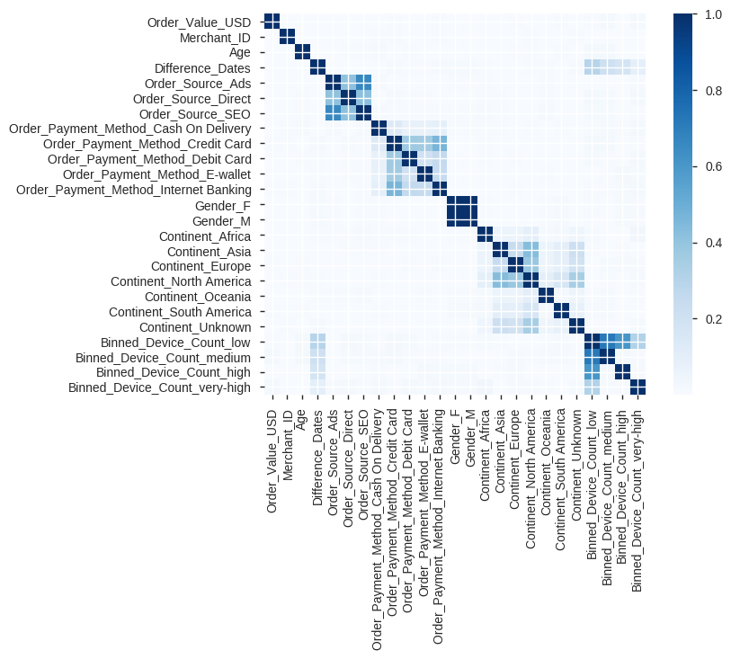

```python
#Correlation matrix
def correlation_matrix_from(dataframe):
    return np.corrcoef(dataframe, rowvar=False)

def corr_plot(dataframe):
    corr_matrix = correlation_matrix_from(dataframe)
    size = len(corr_matrix)

    plt.imshow(np.abs(corr_matrix), cmap=plt.cm.Blues, interpolation='nearest')
    plt.xticks(range(size), dataframe.columns, rotation=90)
    plt.yticks(range(size), dataframe.columns)
    plt.colorbar()
    plt.show()

def least_to_most(dataframe):
    corr_matrix = correlation_matrix_from(dataframe)
    size = len(corr_matrix)

    def sort_correlations():
        abs_corr_matrix = np.abs(corr_matrix)
        arg_sorted = np.argsort(abs_corr_matrix, axis=None)[:-size:2]  # Remove diagonals
        ix, iy = np.unravel_index(arg_sorted, abs_corr_matrix.shape)
        return ix, iy, corr_matrix.ravel()[arg_sorted]

    f1, f2, vals = sort_correlations()
    return list(zip(dataframe.columns[f1], dataframe.columns[f2], vals))


corr_plot(merged_train)
ordered_correlations = least_to_most(merged_train)

print("Most Correlated:")
display(ordered_correlations[-3:])

print("Least Correlated:")
display(ordered_correlations[:3])
```

### Pipeline

```python
numeric_transformer = Pipeline(steps=[
    ('imputer', SimpleImputer(strategy='median')),
    ('scaler', StandardScaler())])


categorical_transformer = Pipeline(steps=[
    ('imputer', SimpleImputer(strategy='most_frequent')),
    ('onehot', OneHotEncoder(handle_unknown='ignore'))])

preprocessor = ColumnTransformer(
    transformers=[
        ('num', numeric_transformer, num_attr),
        ('cat', categorical_transformer, cat_attr)])
```

```python
preprocessor
```

```
ColumnTransformer(n_jobs=None, remainder='drop', sparse_threshold=0.3,
                  transformer_weights=None,
                  transformers=[('num',
                                 Pipeline(memory=None,
                                          steps=[('imputer',
                                                  SimpleImputer(add_indicator=False,
                                                                copy=True,
                                                                fill_value=None,
                                                                missing_values=nan,
                                                                strategy='median',
                                                                verbose=0)),
                                                 ('scaler',
                                                  StandardScaler(copy=True,
                                                                 with_mean=True,
                                                                 with_std=True))],
                                          verbose=False),
                                 ['Age'...
                                  'Order_Source_SEO', 'Order_Value_USD']),
                                ('cat',
                                 Pipeline(memory=None,
                                          steps=[('imputer',
                                                  SimpleImputer(add_indicator=False,
                                                                copy=True,
                                                                fill_value=None,
                                                                missing_values=nan,
                                                                strategy='most_frequent',
                                                                verbose=0)),
                                                 ('onehot',
                                                  OneHotEncoder(categories='auto',
                                                                drop=None,
                                                                dtype=<class 'numpy.float64'>,
                                                                handle_unknown='ignore',
                                                                sparse=True))],
                                          verbose=False),
                                 [])],
                  verbose=False)
```

```python
##Split into train and test

#train and test sets
from sklearn.model_selection import train_test_split
X_train, X_test, Y_train, Y_test = train_test_split(merged_train, Y, test_size = 0.3, random_state= 42)
```

```python
X_train.shape,X_test.shape,Y_train.shape,Y_test.shape
```

```
((37949, 25), (16264, 25), (37949, 1), (16264, 1))
```

### Logistic Regression - 1

```python
clf_logreg = Pipeline(steps=[('preprocessor', preprocessor),
                      ('classifier', LogisticRegression())])
```

```python
clf_logreg.fit(X_train, Y_train)
```

```
Pipeline(memory=None,
         steps=[('preprocessor',
                 ColumnTransformer(n_jobs=None, remainder='drop',
                                   sparse_threshold=0.3,
                                   transformer_weights=None,
                                   transformers=[('num',
                                                  Pipeline(memory=None,
                                                           steps=[('imputer',
                                                                   SimpleImputer(add_indicator=False,
                                                                                 copy=True,
                                                                                 fill_value=None,
                                                                                 missing_values=nan,
                                                                                 strategy='median',
                                                                                 verbose=0)),
                                                                  ('scaler',
                                                                   StandardScaler(copy=True,
                                                                                  with_mean...
                                                                                 dtype=<class 'numpy.float64'>,
                                                                                 handle_unknown='ignore',
                                                                                 sparse=True))],
                                                           verbose=False),
                                                  [])],
                                   verbose=False)),
                ('classifier',
                 LogisticRegression(C=1.0, class_weight=None, dual=False,
                                    fit_intercept=True, intercept_scaling=1,
                                    l1_ratio=None, max_iter=100,
                                    multi_class='auto', n_jobs=None,
                                    penalty='l2', random_state=None,
                                    solver='lbfgs', tol=0.0001, verbose=0,
                                    warm_start=False))],
         verbose=False)
```

```python
train_pred = clf_logreg.predict(X_train)
test_pred = clf_logreg.predict(X_test)

print(clf_logreg.score(X_train, Y_train))
print(clf_logreg.score(X_test, Y_test))
print("\n")
print(confusion_matrix(y_true=Y_train, y_pred = train_pred))

confusion_matrix_test = confusion_matrix(y_true=Y_test, y_pred =  test_pred)
confusion_matrix_test
```

```
0.9406308466626262
0.9415887850467289


[[34278   139]
 [ 2114  1418]]
```

```
array([[14707,    64],
       [  886,   607]])
```

```python
#Accuracy Precision Recall on logistic model

from sklearn.metrics import accuracy_score, precision_score, recall_score, f1_score

print("The accuracy score for train:",accuracy_score(Y_train, train_pred))
print("The precision score for train:",precision_score(Y_train, train_pred))
print("The recall score for train:",recall_score(Y_train, train_pred))
print("The F1 score for train:",f1_score(Y_train, train_pred))
```

```
The accuracy score for train: 0.9406308466626262
The precision score for train: 0.9107257546563905
The recall score for train: 0.4014722536806342
The F1 score for train: 0.5572804087247003
```

```python
print("The accuracy score for test:",accuracy_score(Y_test, test_pred))
print("The precision score for test:",precision_score(Y_test, test_pred))
print("The recall score for test:",recall_score(Y_test, test_pred))
print("The F1 score for test:",f1_score(Y_test, test_pred))
```

```
The accuracy score for test: 0.9415887850467289
The precision score for test: 0.9046199701937406
The recall score for test: 0.40656396517079707
The F1 score for test: 0.5609981515711646
```

```python
model_1_log= clf_logreg.predict(merged_test)
model_1_log
```

```
array([0, 0, 0, ..., 0, 0, 0])
```

```python
final= pd.DataFrame({'Merchant_ID' : merged_test['Merchant_ID'],
                     'Fraudster' : model_1_log})
```

```python
final.to_csv("submission_log_1.csv",index=False)
```

### Build Decision Tree Model - 2

```python
%%time
clf_dt = Pipeline(steps=[('preprocessor', preprocessor),
                      ('classifier', DecisionTreeClassifier())])

dt_param_grid = {'classifier__criterion': ['entropy', 'gini'], 'classifier__max_depth': [6,8,10,12],
                 "classifier__min_samples_split": [2, 10, 20],"classifier__min_samples_leaf": [1, 5, 10]}

dt_grid = GridSearchCV(clf_dt, param_grid=dt_param_grid, cv=5)

dt_grid.fit(X_train,Y_train)
```

```
CPU times: user 1min 23s, sys: 367 ms, total: 1min 23s
Wall time: 1min 23s
```

```python
dt_grid.best_params_
```

```
{'classifier__criterion': 'entropy',
 'classifier__max_depth': 6,
 'classifier__min_samples_leaf': 1,
 'classifier__min_samples_split': 20}
```

```python
train_pred = dt_grid.predict(X_train)
test_pred = dt_grid.predict(X_test)

print(dt_grid.score(X_train, Y_train))
print(dt_grid.score(X_test, Y_test))
```

```
0.9497219953094943
0.947798819478603
```

```python
print("The accuracy score for train:",accuracy_score(Y_train, train_pred))
print("The precision score for train:",precision_score(Y_train, train_pred))
print("The recall score for train:",recall_score(Y_train, train_pred))
print("The F1 score for train:",f1_score(Y_train, train_pred))
```

```
The accuracy score for train: 0.9497219953094943
The precision score for train: 0.9
The recall score for train: 0.5172706681766704
The F1 score for train: 0.656957928802589
```

```python
print("The accuracy score for test:",accuracy_score(Y_test, test_pred))
print("The precision score for test:",precision_score(Y_test, test_pred))
print("The recall score for test:",recall_score(Y_test, test_pred))
print("The F1 score for test:",f1_score(Y_test, test_pred))
```

```
The accuracy score for test: 0.947798819478603
The precision score for test: 0.8538461538461538
The recall score for test: 0.5204286671131949
The F1 score for test: 0.6466916354556804
```

```python
model_2_dt= dt_grid.predict(merged_test)
model_2_dt
```

```
array([0, 0, 0, ..., 0, 1, 0])
```

```python
final= pd.DataFrame({'Merchant_ID' : merged_test['Merchant_ID'],
                     'Fraudster' : model_2_dt})
```

```python
final.to_csv("submission_dt.csv",index=False)
```

### Build Gradient Boosting - 3

```python
clf = Pipeline(steps=[('preprocessor', preprocessor),
                      ('GBM',GradientBoostingClassifier())])
```

```python
%%time
gbm_param_grid = {'GBM__max_depth': [8,10,12,14], 'GBM__subsample': [0.8, 0.3], 'GBM__max_features':[0.2, 0.3],
              'GBM__n_estimators': [10, 20, 30]}

gbm_grid = GridSearchCV(clf, param_grid=gbm_param_grid, cv=3)

gbm_grid.fit(X_train,Y_train)
```

[output not shown]

[output cut: 235 more lines]

[output not shown]

```
CPU times: user 2min 40s, sys: 290 ms, total: 2min 40s
Wall time: 2min 41s
```

```python
gbm_grid.best_params_
```

```
{'GBM__max_depth': 14,
 'GBM__max_features': 0.2,
 'GBM__n_estimators': 30,
 'GBM__subsample': 0.8}
```

```python
train_pred = gbm_grid.predict(X_train)
test_pred = gbm_grid.predict(X_test)

print(gbm_grid.score(X_train, Y_train))
print(gbm_grid.score(X_test, Y_test))
```

```
0.9648212074099449
0.9497663551401869
```

```python
print("The accuracy score for train:",accuracy_score(Y_train, train_pred))
print("The precision score for train:",precision_score(Y_train, train_pred))
print("The recall score for train:",recall_score(Y_train, train_pred))
print("The F1 score for train:",f1_score(Y_train, train_pred))
```

```
The accuracy score for train: 0.9648212074099449
The precision score for train: 1.0
The recall score for train: 0.6220271800679502
The F1 score for train: 0.7669750392738698
```

```python
print("The accuracy score for test:",accuracy_score(Y_test, test_pred))
print("The precision score for test:",precision_score(Y_test, test_pred))
print("The recall score for test:",recall_score(Y_test, test_pred))
print("The F1 score for test:",f1_score(Y_test, test_pred))
```

```
The accuracy score for test: 0.9497663551401869
The precision score for test: 0.8967136150234741
The recall score for test: 0.5117213663764233
The F1 score for test: 0.6515991471215351
```

```python
model_3_gb= gbm_grid.predict(merged_test)
model_3_gb
```

```
array([0, 0, 0, ..., 0, 0, 0])
```

```python
final= pd.DataFrame({'Merchant_ID' : merged_test['Merchant_ID'],
                     'Fraudster' : model_3_gb})
```

```python
final.to_csv("gunjan_B76_3562_submission_gb.csv",index=False)
```

### Build SVM - 4

```python
%%time
svc_lin = Pipeline(steps=[('preprocessor', preprocessor),
                      ('classifier', SVC())])
svc_lin.set_params(classifier__kernel='linear',classifier__C=1,
                   classifier__random_state=123)

svc_lin.fit(X_train,Y_train)
```

```
CPU times: user 10.5 s, sys: 173 ms, total: 10.6 s
Wall time: 10.7 s
```

```python
train_pred = svc_lin.predict(X_train)
test_pred = svc_lin.predict(X_test)

print(svc_lin.score(X_train, Y_train))
print(svc_lin.score(X_test, Y_test))
```

```
0.9406308466626262
0.9415887850467289
```

```python
print(confusion_matrix(y_true=Y_train, y_pred = train_pred))

confusion_matrix_test = confusion_matrix(y_true=Y_test, y_pred =  test_pred)
```

```
[[34278   139]
 [ 2114  1418]]
```

```python
print("The accuracy score for train:",accuracy_score(Y_train, train_pred))
print("The precision score for train:",precision_score(Y_train, train_pred))
print("The recall score for train:",recall_score(Y_train, train_pred))
print("The F1 score for train:",f1_score(Y_train, train_pred))
```

```
The accuracy score for train: 0.9406308466626262
The precision score for train: 0.9107257546563905
The recall score for train: 0.4014722536806342
The F1 score for train: 0.5572804087247003
```

```python
print("The accuracy score for test:",accuracy_score(Y_test, test_pred))
print("The precision score for test:",precision_score(Y_test, test_pred))
print("The recall score for test:",recall_score(Y_test, test_pred))
print("The F1 score for test:",f1_score(Y_test, test_pred))
```

```
The accuracy score for test: 0.9415887850467289
The precision score for test: 0.9046199701937406
The recall score for test: 0.40656396517079707
The F1 score for test: 0.5609981515711646
```

```python
model_4_svm= svc_lin.predict(merged_test)
model_4_svm
```

```
array([0, 0, 0, ..., 0, 0, 0])
```

```python
final= pd.DataFrame({'Merchant_ID' : merged_test['Merchant_ID'],
                     'Fraudster' : model_4_svm})
```

```python
final.to_csv("Gunjan_B76_3562_submission_svm.csv",index=False)
```